# Reading and Writing Vector Data

```python
    # Make sure map has a little space around the data
    minx, miny, maxx, maxy = geometry_bounds(plot_df)
    # Set span_x
    span_x = maxx - minx
    # Set span_y
    span_y = maxy - miny
    # Set pad_x
    pad_x = span_x * 0.08 if span_x else max(abs(minx) * 0.02, 1.0)
    # Set pad_y
    pad_y = span_y * 0.08 if span_y else max(abs(miny) * 0.02, 1.0)
    # Call set_xlim()
    ax.set_xlim(minx - pad_x, maxx + pad_x)
    # Call set_ylim()
    ax.set_ylim(miny - pad_y, maxy + pad_y)
    # Call tight_layout()
    ax.figure.tight_layout()
    # Call show()
    plt.show()
    # Return result
    return len(plot_df)

# Define geometry_bounds()
def geometry_bounds(frame):
    # Find the smallest box that includes all the shapes in the table.
    boxes = []
    # Loop: geom in frame["geometry"]
    for geom in frame["geometry"]:
        # If isinstance(geom, BaseGeometry) and not geom.is_empty
        if isinstance(geom, BaseGeometry) and not geom.is_empty:
            # Call append()
            boxes.append(geom.bounds)
    # If not boxes
    if not boxes:
        # Return result
        return None
    # Return result
    return (
        # Call min()
        min(box[0] for box in boxes),
        # Call min()
        min(box[1] for box in boxes),
        # Call max()
        max(box[2] for box in boxes),
        # Call max()
        max(box[3] for box in boxes),
    # Close multi-line expression
    )

# Define list_layers()
def list_layers(relative):
    # Show info about each 'layer' in a vector dataset/file (like "roads", "buildings" in a file)
    path = _resolve(relative)
    # With open_vectors_data(path) as dataset
    with open_vectors_data(path) as dataset:
        # Call print()
        print(f"{dataset.format_name}  |  driver {dataset.driver}  |  {_file_label(dataset.path)}")
        # Set rows
        rows = []
        # Loop: layer in dataset.layers
        for layer in dataset.layers:
            # Call append()
            rows.append(
                # Statement
                {
                    # Statement
                    "layer": layer.name,
                    # Statement
                    "geometry_type": layer.geometry_type,
                    # Statement
                    "features": layer.feature_count,
                    # Call crs is None else str()
                    "crs": None if layer.crs is None else str(layer.crs),
                    # Call "fields": len()
                    "fields": len(layer.fields),
                # Close mapping or set
                }
            # Close multi-line expression
            )
        # Call display()
        display(pd.DataFrame(rows))

# Define read_vector()
def read_vector(relative, layer=None, title=None, plot=True, limit=None):
    # Open a normal vector file, show all its details, and plot it.
    path = _resolve(relative)
    # Set label
    label = title or path.name
    # With open_vectors_data(path, layer=layer) as dataset
    with open_vectors_data(path, layer=layer) as dataset:
        # Set active
        active = dataset.layer
        # Set frame
        frame = active.to_dataframe(limit=limit)
        # Set read_bounds
        read_bounds = geometry_bounds(frame)
        # Call print()
        print(f"File:             {_file_label(dataset.path)}")
        # Call print()
        print(f"Format:           {dataset.format_name}")
        # Call print()
        print(f"Driver:           {dataset.driver}")
        # Call print()
        print(f"Layer count:      {dataset.layer_count}")
        # Call print()
        print(f"Layer names:      {dataset.layer_names}")
        # Call print()
        print(f"Active layer:     {active.name}")
        # Call print()
        print(f"Geometry type:    {active.geometry_type}")
        # Call print()
        print(f"Geometry source:  {active.geometry_source}")
        # Call print()
        print(f"Feature count:    {active.feature_count}")
        # Call print()
        print(f"Features read:    {len(frame)}")
        # Call print()
        print(f"CRS:              {active.crs}")
        # Call print()
        print(f"Bounds:           {read_bounds if read_bounds is not None else active.bounds}")
        # Call print()
        print("Fields:")
        # Loop: field in active.fields
        for field in active.fields:
            # Set width
            width = f", width={field.width}" if field.width else ""
            # Call print()
            print(f"  - {field.name} ({field.type_name}{width})")
        # If dataset.warnings
        if dataset.warnings:
            # Call print()
            print("Sidecar notes:")
            # Loop: note in dataset.warnings
            for note in dataset.warnings:
                # Call print()
                print(f"  - {note}")
        # Call display()
        display(preview_table(frame))
        # If plot
        if plot:
            # Call plot_frame()
            plot_frame(frame, label)
        # Set feature_count
        feature_count = active.feature_count if active.feature_count is not None else len(frame)
        # Call append()
        RESULTS.append(
            # Statement
            {
                # Call "file": _file_label()
                "file": _file_label(dataset.path),
                # Statement
                "format": dataset.format_name,
                # Statement
                "driver": dataset.driver,
                # Statement
                "layer": active.name,
                # Statement
                "features": feature_count,
                # Call crs is None else str()
                "crs": None if active.crs is None else str(active.crs),
                # Include status": "opened
                "status": "opened",
            # Close mapping or set
            }
        # Close multi-line expression
        )
        # Return result
        return None

# Define read_cloud()
def read_cloud(
    # Statement
    relative,
    # Set layer
    layer=None,
    # Set title
    title=None,
    # Set plot
    plot=True,
    # Set limit
    limit=None,
    # Set bbox
    bbox=None,
    # Set columns
    columns=None,
    # Set where
    where=None,
# Statement
):
    # Include
    """
    # Call Open a 'cloud-native'()
    Open a 'cloud-native' (modern!) vector file, print LOTS of details about it, and plot it.
    # Statement
    Cloud-native just means things like Parquet or GeoParquet: fast, chunked, and can be remote.
    # Statement
    You can even show only part of the data using bbox/columns/where arguments.
    # Include
    """
    # Set path
    path = _resolve(relative)
    # Set label
    label = title or path.name
    # Set print(f"\n{'
    print(f"\n{'=' * 72}\n{label}\n{'=' * 72}")
    # With open_cloud_native_vector_data(path, layer=layer) as dat
    with open_cloud_native_vector_data(path, layer=layer) as dataset:
        # Set active
        active = dataset.layer
        # Set frame
        frame = active.to_dataframe()
        # If limit is not None
        if limit is not None:
            # Set frame
            frame = frame.head(limit)
        # Call print()
        print(f"File:              {_file_label(dataset.path)}")
        # Call print()
        print(f"Format:            {dataset.format_name} ({dataset.format_id})")
        # Call print()
        print(f"Schema:            {dataset.schema_name or 'n/a'}")
        # Call print()
        print(f"Reader:            {dataset.reader}")
        # Call print()
        print(f"Spatial access:    {dataset.spatial_access}")
        # Call print()
        print(f"Spatial index:     {dataset.spatial_index or 'n/a'}")
        # Call print()
        print(f"Geometry encoding: {dataset.geometry_encoding or 'n/a'}")
        # Call print()
        print(f"Layers:            {dataset.layer_count}")
        # Call print()
        print(f"Active layer:      {active.name}")
        # Call print()
        print(f"Features:          {active.feature_count}")
        # Call print()
        print(f"CRS:               {active.crs}")
        # Set extent
        extent = active.bounds if active.bounds is not None else active.compute_bounds()
        # Call print()
        print(f"Extent:            {None if extent is None else extent.to_tuple()}")
        # Call print()
        print("Fields:")
        # Loop: field in active.fields
        for field in active.fields:
            # Call print()
            print(f"  - {field.name} ({field.type_name})")
        # If dataset.warnings
        if dataset.warnings:
            # Call print()
            print("Notes:")
            # Loop: note in dataset.warnings
            for note in dataset.warnings:
                # Call print()
                print(f"  - {note}")
        # Set shown
        shown = frame
        # If bbox is not None or columns is not None or where is not
        if bbox is not None or columns is not None or where is not None:
            # Set shown
            shown = active.to_dataframe(bbox=bbox, columns=columns, where=where, limit=limit)
            # Call print()
            print(f"Filtered rows:     {len(shown)}")
        # Call display()
        display(preview_table(shown))
        # If plot
        if plot:
            # Call plot_frame()
            plot_frame(shown, label)
        # Set feature_count
        feature_count = active.feature_count if active.feature_count is not None else len(frame)
        # Call append()
        RESULTS.append(
            # Statement
            {
                # Call "file": _file_label()
                "file": _file_label(dataset.path),
                # Statement
                "format": dataset.format_name,
                # Statement
                "driver": dataset.reader,
                # Statement
                "layer": active.name,
                # Statement
                "features": feature_count,
                # Call crs is None else str()
                "crs": None if active.crs is None else str(active.crs),
                # Include status": "opened
                "status": "opened",
            # Close mapping or set
            }
        # Close multi-line expression
        )
    # Return result
    return None
```

```python
# 9. Print out the main folders/files so people can see where things are.
print(f"Sample directory: {DATA}")
# Call print()
print(f"County source:    {SOURCE}")
# Call print()
print(f"Write output:     {OUTPUT}")
# Call print()
print(f"GDAL:             {gdal.VersionInfo('--version')}")
```

```
Sample directory: /home/zia207/Github/GeoLattice/Data/00_shared/data_gdal
County source:    /home/zia207/Github/GeoLattice/Data/00_shared/vector_data/USA/NY_County_PROJ.shp
Write output:     /home/zia207/Github/GeoLattice/Data/00_shared/vector_data/output_folder
GDAL:             GDAL 3.13.3 "Iowa City", released 2026/08/13
```

## Part 1: Reading desktop formats

`supported_formats()` lists every file type the desktop reader knows about and whether this GDAL build includes a driver for it. The walkthrough below follows the table in the introduction. GeoPackage and spreadsheets are in this list as well; they use the same `open_vectors_data` call. The cloud-native section later uses `supported_cloud_native_formats()`, which reports a reader rather than a GDAL driver.

## Drivers available for reading

`supported_formats()` lists every file type the desktop reader knows about and whether this GDAL build includes a driver for it.

```python
# Build a catalog of common vector formats and show which drivers are installed
catalog = pd.DataFrame(supported_formats())  # Full format table from geolattice
keep = {
    "ESRI Shapefile",  # Classic multi-file shapefile
    "GeoPackage",  # SQLite-based OGC GeoPackage
    "GeoJSON",  # JSON feature collections
    "GeoJSON Sequence",  # Newline-delimited GeoJSON
    "KML / KMZ",  # Google Earth KML and zipped KMZ
    "GML",  # OGC Geography Markup Language
    "GPX",  # GPS Exchange tracks/waypoints
    "Delimited text (CSV/TXT)",  # CSV/TXT with WKT or XY columns
    "MapInfo TAB / MIF",  # MapInfo binary TAB and text MIF/MID
    "AutoCAD DXF",  # Drawing Exchange Format
    "AutoCAD DWG",  # AutoCAD native drawing
    "MicroStation DGN",  # MicroStation design file
    "ESRI File Geodatabase",  # FileGDB / OpenFileGDB
    "SpatiaLite / SQLite",  # Spatial SQLite database
    "FlatGeobuf",  # Cloud-friendly flat vector format
    "OpenStreetMap",  # OSM XML / PBF
    "Microsoft Excel",  # XLSX via GDAL
    "Microsoft Excel (legacy)",  # Older XLS driver
    "LibreOffice ODS",  # OpenDocument spreadsheet
}
catalog = catalog.loc[catalog["name"].isin(keep)].copy()  # Keep only the formats listed above
catalog["extensions"] = catalog["extensions"].map(lambda names: ", ".join(names))  # Join extensions for display
catalog["drivers"] = catalog["available_drivers"].map(lambda names: ", ".join(names))  # Join driver names
display(
    # Call rename()
    catalog[["name", "extensions", "drivers", "available"]].rename(
        columns={"name": "format", "available": "driver installed"}  # Friendlier column labels
    )
# Close multi-line expression
)
```

|  | format | extensions | drivers | driver installed |
| --- | --- | --- | --- | --- |
| 0 | ESRI Shapefile | .shp | ESRI Shapefile | True |
| 1 | GeoPackage | .gpkg | GPKG | True |
| 2 | GeoJSON | .geojson, .json | GeoJSON | True |
| 3 | GeoJSON Sequence | .geojsonl, .geojsons, .json, .jsonl | GeoJSONSeq | True |
| 4 | KML / KMZ | .kml, .kmz | LIBKML, KML | True |
| 5 | GML | .gml | GML | True |
| 6 | GPX | .gpx | GPX | True |
| 7 | Delimited text (CSV/TXT) | .csv, .txt | CSV | True |
| 8 | MapInfo TAB / MIF | .tab, .mif, .mid | MapInfo File | True |
| 9 | AutoCAD DXF | .dxf | DXF | True |
| 10 | AutoCAD DWG | .dwg | CAD | True |
| 11 | MicroStation DGN | .dgn | DGN | True |
| 12 | ESRI File Geodatabase | .gdb | OpenFileGDB | True |
| 14 | SpatiaLite / SQLite | .sqlite, .sqlite3, .db, .spatialite | SQLite | True |
| 15 | FlatGeobuf | .fgb | FlatGeobuf | True |
| 18 | OpenStreetMap | .osm, .pbf | OSM | True |
| 19 | Microsoft Excel | .xlsx | XLSX | True |
| 20 | Microsoft Excel (legacy) | .xls | XLS | True |
| 21 | LibreOffice ODS | .ods | ODS | True |

### Shapefile

A shapefile is a small group of files that share one basename. `.shp` holds geometry, `.shx` is the index, and `.dbf` holds attributes. `.prj` stores the CRS and `.cpg` stores the DBF encoding. Natural Earth, TIGER/Line, and the NYS GIS Clearinghouse still publish this format.

`poly.shp` is the classic GDAL polygon sample. It is in British National Grid (EPSG:27700) and carries `AREA`, `EAS_ID`, and `PRFEDEA`.

```
File:             poly.shp
Format:           ESRI Shapefile
Driver:           ESRI Shapefile
Layer count:      1
Layer names:      ['poly']
Active layer:     poly
Geometry type:    Polygon
Geometry source:  layer
Feature count:    10
Features read:    10
CRS:              EPSG:27700
Bounds:           (478315.53125, 4762880.5, 481645.3125, 4765610.5)
Fields:
  - AREA (Real, width=12)
  - EAS_ID (Integer64, width=11)
  - PRFEDEA (String, width=16)
```

|  | fid | geom_type | AREA | EAS_ID | PRFEDEA |
| --- | --- | --- | --- | --- | --- |
| 0 | 0 | Polygon | 215229.266 | 168 | 35043411 |
| 1 | 1 | Polygon | 247328.172 | 179 | 35043423 |
| 2 | 2 | Polygon | 261752.781 | 171 | 35043414 |
| 3 | 3 | Polygon | 547597.188 | 173 | 35043416 |
| 4 | 4 | Polygon | 15775.758 | 172 | 35043415 |

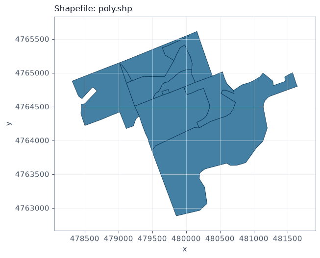

```python
# Read and preview the sample shapefile poly.shp
read_vector("poly.shp", title="Shapefile: poly.shp")  # Open, summarize, and plot poly.shp
```

### GeoJSON

GeoJSON is a single JSON document: a Feature, a FeatureCollection, or a bare geometry. City open-data portals and the USGS earthquake feeds offer it as a download. Coordinates in a GeoJSON file are longitude, latitude (EPSG:4326) unless the file says otherwise.

`geojson/grenada.geojson` is one administrative polygon for Grenada, with names and ISO codes in the properties.

```
File:             geojson/grenada.geojson
Format:           GeoJSON
Driver:           GeoJSON
Layer count:      1
Layer names:      ['grenada']
Active layer:     grenada
Geometry type:    Multi Polygon
Geometry source:  layer
Feature count:    1
Features read:    1
CRS:              EPSG:4326
Bounds:           (-62.0065868, 11.786, -61.173214300000005, 12.5966532)
Fields:
  - flag (String)
  - name (String)
  - name:cs (String)
  - name:de (String)
  - name:en (String)
  - name:eo (String)
  - name:fr (String)
  - name:fy (String)
  - name:hr (String)
  - name:nl (String)
  - name:ru (String)
  - name:sl (String)
  - name:ta (String)
  - name:uk (String)
  - boundary (String)
  - name:tzl (String)
  - timezone (String)
  - wikidata (String)
  - ISO3166-1 (String)
  - wikipedia (String)
  - admin_level (String)
  - is_in:continent (String)
  - ISO3166-1:alpha2 (String)
  - ISO3166-1:alpha3 (String)
  - ISO3166-1:numeric (String)
```

|  | fid | geom_type | flag | name | name:cs | name:de | name:en | name:eo |
| --- | --- | --- | --- | --- | --- | --- | --- | --- |
| 0 | 550727 | MultiPolygon | http://upload.wikimedia.org/wikipedia/common... | Grenada | Grenada | Grenada | Grenada | Grenado |

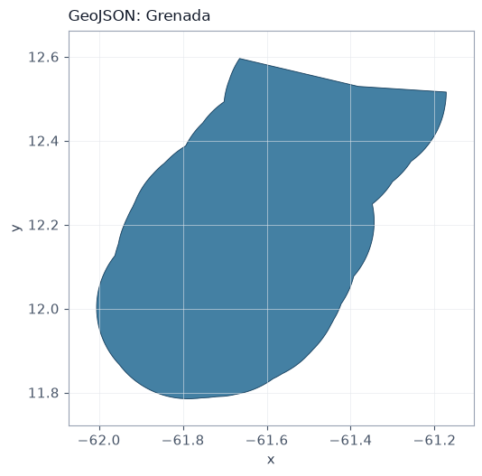

```python
# Read and preview the Grenada GeoJSON sample
read_vector("geojson/grenada.geojson", title="GeoJSON: Grenada")  # Open Grenada polygons from GeoJSON
```

### GeoJSON Sequence

GeoJSON Sequence (also called GeoJSON Text Sequences, or newline-delimited GeoJSON) stores one feature per line. The extensions here are `.geojsonl` and `.geojsons`. A download is often produced with `ogr2ogr -f GeoJSONSeq`.

`geojsonseq/test.geojsonl` has two points and a `foo` attribute. The same file is opened again later with `open_cloud_native_vector_data`, which streams one feature per line.

```
File:             geojsonseq/test.geojsonl
Format:           GeoJSON Sequence
Driver:           GeoJSONSeq
Layer count:      1
Layer names:      ['test']
Active layer:     test
Geometry type:    Point
Geometry source:  layer
Feature count:    2
Features read:    2
CRS:              EPSG:4326
Bounds:           (1.0, 2.0, 3.0, 4.0)
Fields:
  - foo (String)
```

|  | fid | geom_type | foo |
| --- | --- | --- | --- |
| 0 | 0 | Point | bar |
| 1 | 1 | Point | baz |

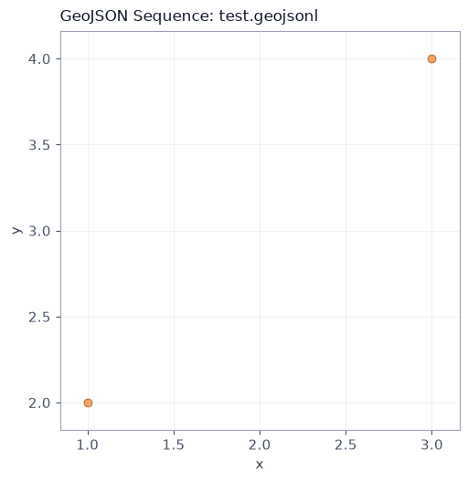

```python
# Read and preview a GeoJSON Sequence (.geojsonl) sample
read_vector("geojsonseq/test.geojsonl", title="GeoJSON Sequence: test.geojsonl")  # Open newline-delimited GeoJSON
```

### KML and KMZ

KML is the XML format used by Google Earth. A KMZ file is a zip archive with a KML document inside, usually named `doc.kml`. USGS earthquake feeds, Google's KML samples, and National Weather Service warning products are common sources.

`kml/samples.kml` is a Google sample document. Each folder becomes a layer, and those layers sit in different parts of the world, so they are drawn separately. This sample collection has no `.kmz` file. The last cell zips `kml/placemark.kml` into a temporary KMZ and opens that archive, which is the path `open_vectors_data` uses for KMZ.

```python
# List layers inside the sample KML file
list_layers("kml/samples.kml")  # Print each KML layer name, geom type, and feature count
```

```
KML / KMZ  |  driver LIBKML  |  kml/samples.kml
```

|  | layer | geometry_type | features | crs | fields |
| --- | --- | --- | --- | --- | --- |
| 0 | Placemarks | Unknown (any) | 3 | EPSG:4326 | 12 |
| 1 | Styles and Markup | Unknown (any) | 1 | EPSG:4326 | 12 |
| 2 | Highlighted Icon | Unknown (any) | 1 | EPSG:4326 | 12 |
| 3 | Ground Overlays | Unknown (any) | 1 | EPSG:4326 | 12 |
| 4 | Screen Overlays | Unknown (any) | 0 | EPSG:4326 | 12 |
| 5 | Paths | Unknown (any) | 6 | EPSG:4326 | 12 |
| 6 | Polygons | Unknown (any) | 0 | EPSG:4326 | 12 |
| 7 | Google Campus | Unknown (any) | 4 | EPSG:4326 | 12 |
| 8 | Extruded Polygon | Unknown (any) | 1 | EPSG:4326 | 12 |
| 9 | Absolute and Relative | Unknown (any) | 4 | EPSG:4326 | 12 |

```
File:             kml/samples.kml
Format:           KML / KMZ
Driver:           LIBKML
Layer count:      10
Layer names:      ['Placemarks', 'Styles and Markup', 'Highlighted Icon', 'Ground Overlays', 'Screen Overlays', 'Paths', 'Polygons', 'Google Campus', 'Extruded Polygon', 'Absolute and Relative']
Active layer:     Google Campus
Geometry type:    Unknown (any)
Geometry source:  layer
Feature count:    4
Features read:    4
CRS:              EPSG:4326
Bounds:           (-122.0860162273783, 37.42129328840593, -122.0828502269665, 37.42281815323651)
Fields:
  - id (String)
  - Name (String)
  - description (String)
  - timestamp (DateTime)
  - begin (DateTime)
  - end (DateTime)
  - altitudeMode (String)
  - tessellate (Integer)
  - extrude (Integer)
  - visibility (Integer)
  - drawOrder (Integer)
  - icon (String)
```

|  | fid | geom_type | id | Name | description | timestamp | begin | end |
| --- | --- | --- | --- | --- | --- | --- | --- | --- |
| 0 | 1 | Polygon | None | Building 40 | None | None | None | None |
| 1 | 2 | Polygon | None | Building 41 | None | None | None | None |
| 2 | 3 | Polygon | None | Building 42 | None | None | None | None |
| 3 | 4 | Polygon | None | Building 43 | None | None | None | None |

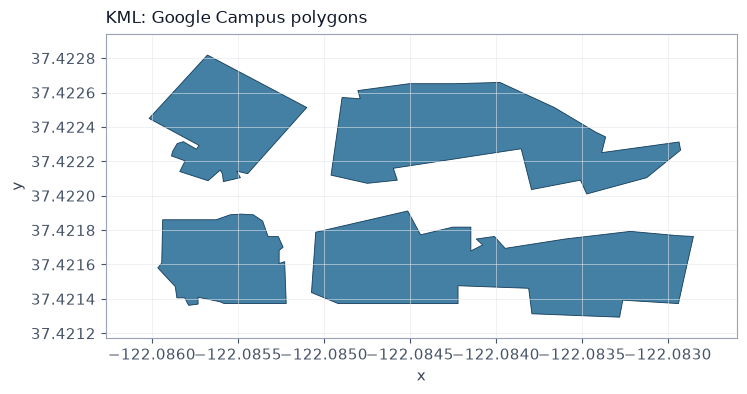

```python
# Read the Google Campus polygon layer from the sample KML
read_vector(
    "kml/samples.kml",  # Multi-layer KML sample
    layer="Google Campus",  # Select the campus polygons layer
    title="KML: Google Campus polygons",  # Plot title
)
```

```
File:             kml/samples.kml
Format:           KML / KMZ
Driver:           LIBKML
Layer count:      10
Layer names:      ['Placemarks', 'Styles and Markup', 'Highlighted Icon', 'Ground Overlays', 'Screen Overlays', 'Paths', 'Polygons', 'Google Campus', 'Extruded Polygon', 'Absolute and Relative']
Active layer:     Paths
Geometry type:    Unknown (any)
Geometry source:  layer
Feature count:    6
Features read:    6
CRS:              EPSG:4326
Bounds:           (-112.2695268555611, 36.07954952145647, -112.080622229595, 36.10677870477137)
Fields:
  - id (String)
  - Name (String)
  - description (String)
  - timestamp (DateTime)
  - begin (DateTime)
  - end (DateTime)
  - altitudeMode (String)
  - tessellate (Integer)
  - extrude (Integer)
  - visibility (Integer)
  - drawOrder (Integer)
  - icon (String)
```

|  | fid | geom_type | id | Name | description | timestamp | begin | end |
| --- | --- | --- | --- | --- | --- | --- | --- | --- |
| 0 | 1 | LineString | None | Tessellated | If the <tessellate> tag has a value of 1, th... | None | None | None |
| 1 | 2 | LineString | None | Untessellated | If the <tessellate> tag has a value of 0, th... | None | None | None |
| 2 | 3 | LineString | None | Absolute | Transparent purple line | None | None | None |
| 3 | 4 | LineString | None | Absolute Extruded | Transparent green wall with yellow outlines | None | None | None |
| 4 | 5 | LineString | None | Relative | Black line (10 pixels wide), height tracks t... | None | None | None |

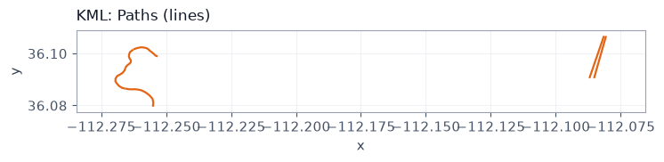

```python
# Read the Paths line layer from the sample KML
read_vector(
    "kml/samples.kml",  # Same multi-layer KML sample
    layer="Paths",  # Select the line Paths layer
    title="KML: Paths (lines)",  # Plot title
)
```

```
File:             /tmp/geolattice_kmz_sg0gshm5/placemark.kmz
Format:           KML / KMZ
Driver:           LIBKML
Layer count:      1
Layer names:      ['placemark']
Active layer:     placemark
Geometry type:    Unknown (any)
Geometry source:  layer
Feature count:    1
Features read:    1
CRS:              EPSG:4326
Bounds:           (2.0, 49.0, 2.0, 49.0)
Fields:
  - id (String)
  - Name (String)
  - description (String)
  - timestamp (DateTime)
  - begin (DateTime)
  - end (DateTime)
  - altitudeMode (String)
  - tessellate (Integer)
  - extrude (Integer)
  - visibility (Integer)
  - drawOrder (Integer)
  - icon (String)
```

|  | fid | geom_type | id | Name | description | timestamp | begin | end |
| --- | --- | --- | --- | --- | --- | --- | --- | --- |
| 0 | 1 | Point | None | Simple placemark | Some<br></br>HTML<br></br>content | None | None | None |

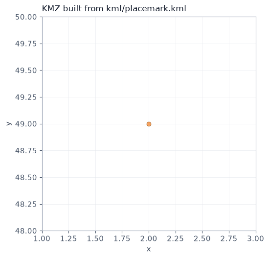

```python
# Build a KMZ from placemark.kml and read it back
kmz_dir = Path(tempfile.mkdtemp(prefix="geolattice_kmz_"))  # Temp directory for the KMZ
kmz_path = kmz_dir / "placemark.kmz"  # Output KMZ path
with zipfile.ZipFile(kmz_path, "w", compression=zipfile.ZIP_DEFLATED) as archive:  # Create zipped KMZ
    archive.write(DATA / "kml" / "placemark.kml", arcname="doc.kml")  # Store KML as doc.kml inside the zip

read_vector(kmz_path, title="KMZ built from kml/placemark.kml")  # Read the KMZ we just created
```

### GML

GML is the OGC XML encoding used by INSPIRE downloads, Ordnance Survey OpenData, and WFS GetFeature responses. A dataset can contain several layers, and the CRS is declared on the features or the envelope.

`gml/gnis_pop_110.gml` is a small WFS extract of populated places. Each feature is a point with a name and a population.

```
File:             gml/gnis_pop_110.gml
Format:           GML
Driver:           GML
Layer count:      1
Layer names:      ['gnis_pop']
Active layer:     gnis_pop
Geometry type:    Point
Geometry source:  layer
Feature count:    20
Features read:    20
CRS:              EPSG:4326
Bounds:           (-80.17, -13.32, 76.58, 51.0)
Fields:
  - gml_id (String)
  - name (StringList)
  - lowerCorner (String, width=13)
  - upperCorner (String, width=13)
  - population (Integer)
  - country (String, width=24)
  - type (String, width=5)
```

|  | fid | geom_type | gml_id | name | lowerCorner | upperCorner | population | country |
| --- | --- | --- | --- | --- | --- | --- | --- | --- |
| 0 | 148604 | Point | gnis_pop.148604 | [Aflu, Aflu] | 34.12 2.09 | 34.12 2.09 | 84683 | Algeria |
| 1 | 148605 | Point | gnis_pop.148605 | [Altenberga, Altenberga] | 50.83 11.53 | 50.83 11.53 | 731 | Germany |
| 2 | 148606 | Point | gnis_pop.148606 | [Alto de la Estancia, Alto de la Estancia] | 8.6 -80.17 | 8.6 -80.17 | 1081 | Panama |
| 3 | 148607 | Point | gnis_pop.148607 | [Andarab, Andarab] | 35.62 69.21 | 35.62 69.21 | 27034 | Afghanistan |
| 4 | 148608 | Point | gnis_pop.148608 | [Arco, Arco] | 45.92 10.87 | 45.92 10.87 | 15373 | Italy |

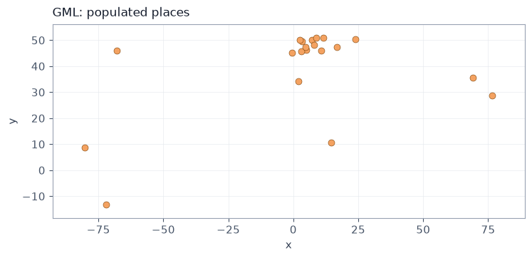

```python
# Read populated places from the sample GML file
read_vector("gml/gnis_pop_110.gml", title="GML: populated places")  # Open GML points of populated places
```

### GPX

GPX is the GPS exchange format written by Garmin, Strava, and OpenStreetMap trace uploads. GDAL exposes five layers: `waypoints`, `routes`, `tracks`, `route_points`, and `track_points`. The sample below is a small GPX 1.1 file. Tracks and waypoints are the two layers with coordinates worth drawing.

```python
# List layers inside the sample GPX file
list_layers("gpx/test.gpx")  # Show GPX layers (tracks, routes, waypoints, ...)
```

```
GPX  |  driver GPX  |  gpx/test.gpx
```

|  | layer | geometry_type | features | crs | fields |
| --- | --- | --- | --- | --- | --- |
| 0 | waypoints | Point | 2 | EPSG:4326 | 23 |
| 1 | routes | Line String | 2 | EPSG:4326 | 12 |
| 2 | tracks | Multi Line String | 3 | EPSG:4326 | 12 |
| 3 | route_points | Point | 3 | EPSG:4326 | 25 |
| 4 | track_points | Point | 4 | EPSG:4326 | 26 |

```
File:             gpx/test.gpx
Format:           GPX
Driver:           GPX
Layer count:      5
Layer names:      ['waypoints', 'routes', 'tracks', 'route_points', 'track_points']
Active layer:     tracks
Geometry type:    Multi Line String
Geometry source:  layer
Feature count:    3
Features read:    3
CRS:              EPSG:4326
Bounds:           (15.0, 14.0, 24.0, 23.0)
Fields:
  - name (String)
  - cmt (String)
  - desc (String)
  - src (String)
  - link1_href (String)
  - link1_text (String)
  - link1_type (String)
  - link2_href (String)
  - link2_text (String)
  - link2_type (String)
  - number (Integer)
  - type (String)
```

|  | fid | geom_type | name | cmt | desc | src | link1_href | link1_text |
| --- | --- | --- | --- | --- | --- | --- | --- | --- |
| 0 | 0 | MultiLineString | track name | None | None | None | None | None |
| 1 | 1 | NaN | empty track | None | None | None | None | None |
| 2 | 2 | NaN | empty track 2 | None | None | None | None | None |

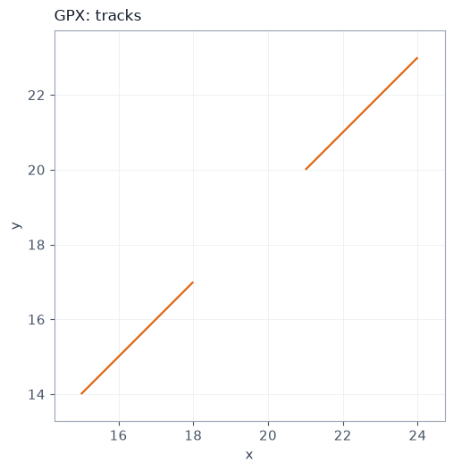

```python
# Read the tracks layer from the sample GPX file
read_vector("gpx/test.gpx", layer="tracks", title="GPX: tracks")  # Open GPX track lines
```

```
File:             gpx/test.gpx
Format:           GPX
Driver:           GPX
Layer count:      5
Layer names:      ['waypoints', 'routes', 'tracks', 'route_points', 'track_points']
Active layer:     waypoints
Geometry type:    Point
Geometry source:  layer
Feature count:    2
Features read:    2
CRS:              EPSG:4326
Bounds:           (1.0, 0.0, 4.0, 3.0)
Fields:
  - ele (Real)
  - time (DateTime)
  - magvar (Real)
  - geoidheight (Real)
  - name (String)
  - cmt (String)
  - desc (String)
  - src (String)
  - link1_href (String)
  - link1_text (String)
  - link1_type (String)
  - link2_href (String)
  - link2_text (String)
  - link2_type (String)
  - sym (String)
  - type (String)
  - fix (String)
  - sat (Integer)
  - hdop (Real)
  - vdop (Real)
  - pdop (Real)
  - ageofdgpsdata (Real)
  - dgpsid (Integer)
```

|  | fid | geom_type | ele | time | magvar | geoidheight | name | cmt |
| --- | --- | --- | --- | --- | --- | --- | --- | --- |
| 0 | 0 | Point | 2.0 | 2007-11-25T17:58:00+01:00 | None | None | waypoint name | waypoint comment |
| 1 | 1 | Point | NaN | NaN | None | None | NaN | NaN |

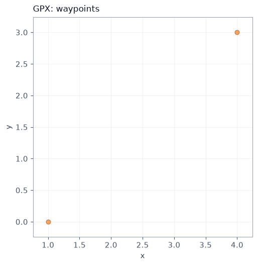

```python
# Read the waypoints layer from the sample GPX file
read_vector("gpx/test.gpx", layer="waypoints", title="GPX: waypoints")  # Open GPX waypoint points
```

### CSV with X/Y or WKT

Delimited text becomes a vector layer when a column holds WKT, or when two columns hold X and Y (longitude and latitude, easting and northing). Earthquake CSV feeds, NOAA station lists, and many data.gov tables are published this way.

Column names the reader checks are printed below. `wkt.csv` uses a `WKT` column of polygons, so the geometry is built from that column. Pass `x_possible_names` and `y_possible_names` when a table uses a different pair, such as `lon` and `lat`.

```
X / longitude: longitude, lon, long, x, easting, east, x_coord, xcoord
Y / latitude:  latitude, lat, y, northing, north, y_coord, ycoord
WKT:           wkt, geom, geometry, the_geom, wkb_geometry
File:             wkt.csv
Format:           Delimited text (CSV/TXT)
Driver:           CSV
Layer count:      1
Layer names:      ['wkt']
Active layer:     wkt
Geometry type:    Unknown (any)
Geometry source:  layer
Feature count:    None
Features read:    3
CRS:              None
Bounds:           (1.001, 1.001, 7.25, 6.25)
Fields:
  - Counter (Integer)
  - WKT (String)
  - Desc (String)
```

|  | fid | geom_type | Counter | WKT | Desc |
| --- | --- | --- | --- | --- | --- |
| 0 | 1 | Polygon | 1 | POLYGON((6.25 1.25,7.25 1.25,7.25 2.25,6.25 ... |  |
| 1 | 2 | Polygon | 2 | POLYGON((4.25 4.25,6.25 4.25,6.25 6.25,4.25 ... |  |
| 2 | 3 | Polygon | 3 | POLYGON((1.001 1.001,3.999 3.999,3.2 1.6,1.0... |  |

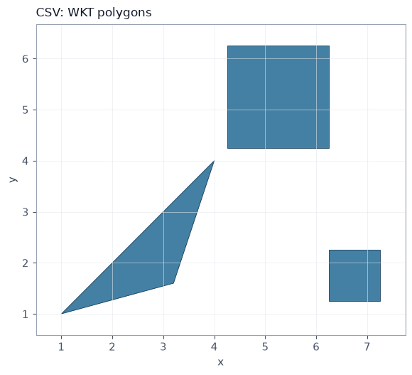

```python
# Show CSV geometry column aliases, then read WKT polygons from CSV
print("X / longitude:", ", ".join(X_POSSIBLE_NAMES))  # Accepted X / longitude column names
print("Y / latitude: ", ", ".join(Y_POSSIBLE_NAMES))  # Accepted Y / latitude column names
print("WKT:          ", ", ".join(GEOM_POSSIBLE_NAMES))  # Accepted WKT geometry column names
read_vector("wkt.csv", title="CSV: WKT polygons")  # Read polygons encoded as WKT in CSV
```

### MapInfo TAB and MIF/MID

MapInfo TAB is a binary workspace: `.tab`, `.map`, `.dat` (or `.dbf`), and `.id`. MIF/MID is the text interchange pair. `.mif` holds geometry and `.mid` holds attributes. Australian open data, including Geoscience Australia, still publishes both.

Opening a `.mid` path reads the sibling `.mif`. `all_geoms.tab` mixes points, lines, and polygons. `small.mif` is two polygons.

```
File:             mitab/all_geoms.tab
Format:           MapInfo TAB / MIF
Driver:           MapInfo File
Layer count:      1
Layer names:      ['all_geoms']
Active layer:     all_geoms
Geometry type:    Unknown (any)
Geometry source:  layer
Feature count:    16
Features read:    16
CRS:              LOCAL_CS["Nonearth",UNIT["Meter",1],AXIS["Easting",EAST],AXIS["Northing",NORTH]]
Bounds:           (-1.0, -1.0, 5.0, 6.0)
Fields:
  - NAME (String, width=1)
```

|  | fid | geom_type | NAME |
| --- | --- | --- | --- |
| 0 | 1 | Point |  |
| 1 | 2 | Point |  |
| 2 | 3 | Point |  |
| 3 | 4 | LineString |  |
| 4 | 5 | LineString |  |

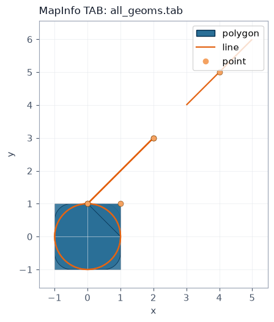

```python
# Read the MapInfo TAB sample with mixed geometries
read_vector("mitab/all_geoms.tab", title="MapInfo TAB: all_geoms.tab")  # Open MapInfo TAB with mixed geom types
```

```
File:             mitab/small.mif
Format:           MapInfo TAB / MIF
Driver:           MapInfo File
Layer count:      1
Layer names:      ['small']
Active layer:     small
Geometry type:    Unknown (any)
Geometry source:  layer
Feature count:    2
Features read:    2
CRS:              LOCAL_CS["Nonearth",UNIT["Meter",1],AXIS["Easting",EAST],AXIS["Northing",NORTH]]
Bounds:           (407128.974, 155312.559, 407142.741, 155329.616)
Fields:
  - NAME (String, width=50)
  - DATA (Integer)
  - OWNER (String, width=64)
  - APPRAISED_VALUE (Real)
  - TAXES (Real)
  - FLOODZONE (Integer)
  - NUM (String, width=254)
```

|  | fid | geom_type | NAME | DATA | OWNER | APPRAISED_VALUE | TAXES | FLOODZONE |
| --- | --- | --- | --- | --- | --- | --- | --- | --- |
| 0 | 1 | Polygon | S. 11th St. | 4 | Shiffer James A and Martha L | 56115.58 | 637.68 | 10 |
| 1 | 2 | Polygon | S. 11th St. | 4 | Guarino "Chucky" Sandra | 62480.53 | 710.01 | 10 |

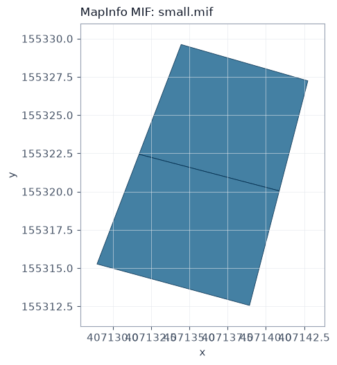

```python
# Read the MapInfo MIF sample
read_vector("mitab/small.mif", title="MapInfo MIF: small.mif")  # Open MapInfo MIF text transfer format
```

```
File:             mitab/small.mif
Format:           MapInfo TAB / MIF
Driver:           MapInfo File
Layer count:      1
Layer names:      ['small']
Active layer:     small
Geometry type:    Unknown (any)
Geometry source:  layer
Feature count:    2
Features read:    2
CRS:              LOCAL_CS["Nonearth",UNIT["Meter",1],AXIS["Easting",EAST],AXIS["Northing",NORTH]]
Bounds:           (407128.974, 155312.559, 407142.741, 155329.616)
Fields:
  - NAME (String, width=50)
  - DATA (Integer)
  - OWNER (String, width=64)
  - APPRAISED_VALUE (Real)
  - TAXES (Real)
  - FLOODZONE (Integer)
  - NUM (String, width=254)
```

|  | fid | geom_type | NAME | DATA | OWNER | APPRAISED_VALUE | TAXES | FLOODZONE |
| --- | --- | --- | --- | --- | --- | --- | --- | --- |
| 0 | 1 | Polygon | S. 11th St. | 4 | Shiffer James A and Martha L | 56115.58 | 637.68 | 10 |
| 1 | 2 | Polygon | S. 11th St. | 4 | Guarino "Chucky" Sandra | 62480.53 | 710.01 | 10 |

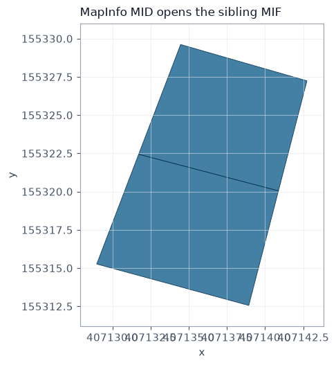

```python
# Open a MapInfo MID file (resolves the sibling MIF)
read_vector("mitab/small.mid", title="MapInfo MID opens the sibling MIF")  # MID alone resolves paired MIF
```

### DXF and DWG

DXF is Autodesk's text drawing exchange. DWG is the binary drawing format. GDAL reads DXF with the DXF driver and DWG with the CAD driver (`libopencad`), which covers older DWG releases. Municipal CAD portals and engineering archives are the usual source.

`dxf/assorted.dxf` mixes lines and points in one `entities` layer. `cad/line_r2000.dwg` is a single R2000 line. A newer DWG that this CAD driver does not recognize is reported as an open error rather than an empty layer.

```
File:             dxf/assorted.dxf
Format:           AutoCAD DXF
Driver:           DXF
Layer count:      1
Layer names:      ['entities']
Active layer:     entities
Geometry type:    Unknown (any)
Geometry source:  layer
Feature count:    22
Features read:    22
CRS:              None
Bounds:           (23.48428829929677, 90.80890168656494, 116.81421207302856, 160.0)
Fields:
  - Layer (String)
  - PaperSpace (Integer)
  - SubClasses (String)
  - Linetype (String)
  - EntityHandle (String)
  - Text (String)
```

|  | fid | geom_type | Layer | PaperSpace | SubClasses | Linetype | EntityHandle | Text |
| --- | --- | --- | --- | --- | --- | --- | --- | --- |
| 0 | 0 | LineString | 0 | None | AcDbEntity:AcDbEllipse | ByLayer | 43 | NaN |
| 1 | 1 | LineString | 0 | None | AcDbEntity:AcDbEllipse | ByLayer | 44 | NaN |
| 2 | 2 | Point | 0 | None | AcDbEntity:AcDbPoint | ByLayer | 45 | NaN |
| 3 | 3 | LineString | 0 | None | AcDbEntity:AcDbLine | ByLayer | 46 | NaN |
| 4 | 4 | Point | 0 | None | AcDbEntity:AcDbMText | ByLayer | 47 | Test |

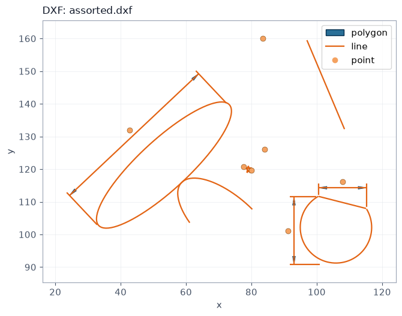

```python
# Read the AutoCAD DXF sample
read_vector("dxf/assorted.dxf", title="DXF: assorted.dxf")  # Open AutoCAD DXF drawing entities
```

```
File:             cad/line_r2000.dwg
Format:           AutoCAD DWG
Driver:           CAD
Layer count:      1
Layer names:      ['0']
Active layer:     0
Geometry type:    Line String
Geometry source:  layer
Feature count:    1
Features read:    1
CRS:              None
Bounds:           (50.0, 50.0, 100.0, 100.0)
Fields:
  - cadgeom_type (String)
  - thickness (Real)
  - color (String)
  - extentity_data (String)
  - text (String)
```

|  | fid | geom_type | cadgeom_type | thickness | color | extentity_data | text |
| --- | --- | --- | --- | --- | --- | --- | --- |
| 0 | 0 | LineString | CADLine | 0.0 | #FFFFFFFF | None | None |

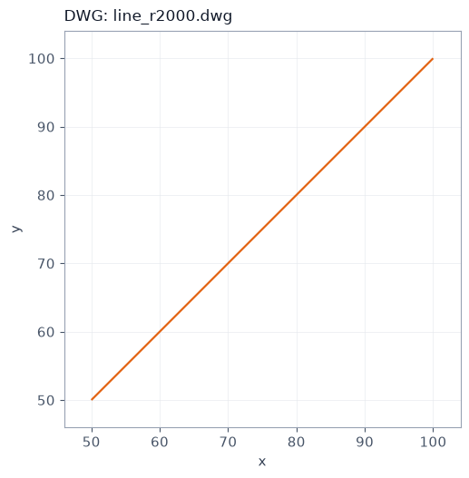

```python
# Read the AutoCAD DWG sample
read_vector("cad/line_r2000.dwg", title="DWG: line_r2000.dwg")  # Open AutoCAD DWG drawing
```

### DGN

DGN is Bentley's MicroStation design format. State DOT CADD downloads are a common source.

```
File:             dgn/smalltest.dgn
Format:           MicroStation DGN
Driver:           DGN
Layer count:      1
Layer names:      ['elements']
Active layer:     elements
Geometry type:    Unknown (any)
Geometry source:  layer
Feature count:    4
Features read:    4
CRS:              None
Bounds:           (0.32859341610857307, -0.09610658389142834, 9.68780658389143, 9.263106583891428)
Fields:
  - Type (Integer, width=2)
  - Level (Integer, width=2)
  - GraphicGroup (Integer, width=4)
  - ColorIndex (Integer, width=3)
  - Weight (Integer, width=2)
  - Style (Integer, width=1)
  - EntityNum (Integer)
  - MSLink (Integer)
  - Text (String)
  - ULink (String)
```

|  | fid | geom_type | Type | Level | GraphicGroup | ColorIndex | Weight | Style |
| --- | --- | --- | --- | --- | --- | --- | --- | --- |
| 0 | 11 | Point | 17 | 1 | 0 | 0 | 0 | 0 |
| 1 | 12 | LineString | 15 | 2 | 0 | 0 | 0 | 0 |
| 2 | 13 | Polygon | 6 | 2 | 0 | 83 | 0 | 0 |
| 3 | 14 | LineString | 3 | 2 | 0 | 83 | 0 | 0 |

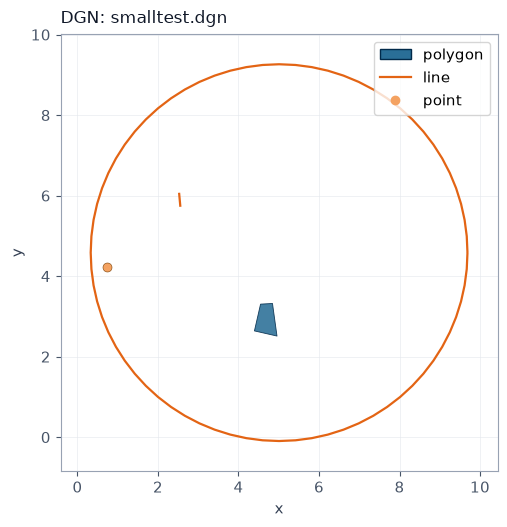

```python
# Read the MicroStation DGN sample
read_vector("dgn/smalltest.dgn", title="DGN: smalltest.dgn")  # Open MicroStation DGN design file
```

### File Geodatabase

An Esri File Geodatabase is a directory whose name ends in `.gdb`. USGS National Map products (NHD, Watershed Boundary Dataset) and TIGER/Line geodatabases use it. OpenFileGDB reads the directory without the Esri FileGDB SDK.

`openfilegdb/polygon_golden.gdb` holds one multipolygon in EPSG:4326.

```
File:             openfilegdb/polygon_golden.gdb
Format:           ESRI File Geodatabase
Driver:           OpenFileGDB
Layer count:      1
Layer names:      ['OGRGeoJSON']
Active layer:     OGRGeoJSON
Geometry type:    Multi Polygon
Geometry source:  layer
Feature count:    1
Features read:    1
CRS:              EPSG:4326
Bounds:           (0.0, 0.0, 1.0, 1.0)
Fields:
  - foo (String)
```

|  | fid | geom_type | foo |
| --- | --- | --- | --- |
| 0 | 1 | MultiPolygon | bar |

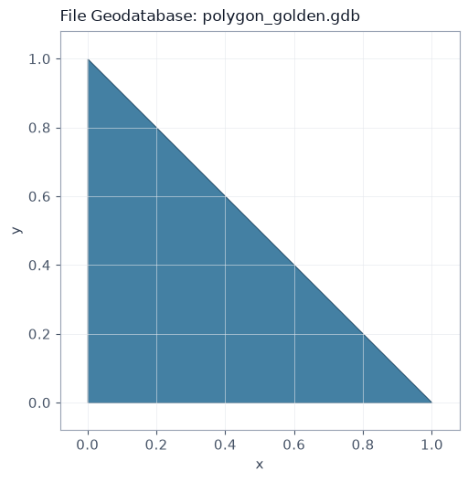

```python
# Read polygons from an ESRI File Geodatabase sample
read_vector(
    "openfilegdb/polygon_golden.gdb",  # FileGDB folder dataset
    title="File Geodatabase: polygon_golden.gdb",  # Plot title
)
```

### SpatiaLite and SQLite

SpatiaLite stores vectors inside a SQLite database. Natural Earth offers a SQLite download, and the Gaia-SINS site publishes sample databases. The SQLite driver reads SpatiaLite geometry when GDAL is built with SpatiaLite.

`sqlite/poly_spatialite.sqlite` is the same polygon set as `poly.shp`, stored as a SpatiaLite layer named `poly`.

```
File:             sqlite/poly_spatialite.sqlite
Format:           SpatiaLite / SQLite
Driver:           SQLite
Layer count:      1
Layer names:      ['poly']
Active layer:     poly
Geometry type:    Polygon
Geometry source:  layer
Feature count:    10
Features read:    10
CRS:              None
Bounds:           (478315.53125, 4762880.5, 481645.3125, 4765610.5)
Fields:
  - area (Real)
  - eas_id (Real)
  - prfedea (String)
```

|  | fid | geom_type | area | eas_id | prfedea |
| --- | --- | --- | --- | --- | --- |
| 0 | 1 | Polygon | 215229.266 | 168.0 | 35043411 |
| 1 | 2 | Polygon | 247328.172 | 179.0 | 35043423 |
| 2 | 3 | Polygon | 261752.781 | 171.0 | 35043414 |
| 3 | 4 | Polygon | 547597.188 | 173.0 | 35043416 |
| 4 | 5 | Polygon | 15775.758 | 172.0 | 35043415 |

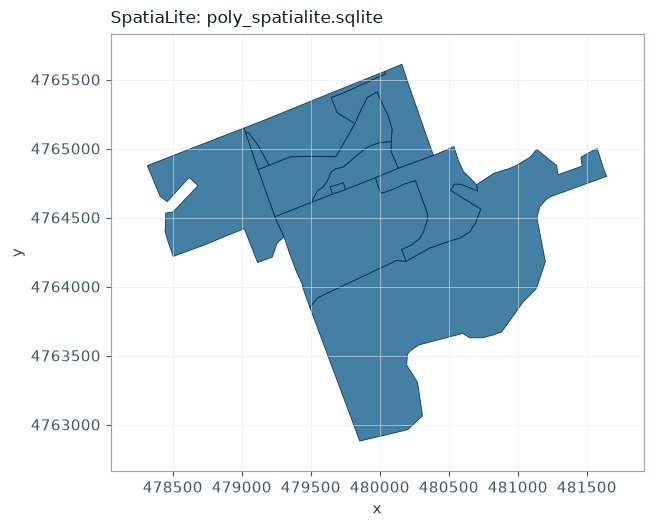

```python
# Read polygons from a SpatiaLite / SQLite sample
read_vector(
    "sqlite/poly_spatialite.sqlite",  # SpatiaLite database file
    title="SpatiaLite: poly_spatialite.sqlite",  # Plot title
)
```

### FlatGeobuf

FlatGeobuf (`.fgb`) is a single binary file with a spatial index packed into the header, which makes it practical to read from cloud storage. The format's own test data, including country and county extracts, lives in the flatgeobuf repository.

`testfgb/poly.fgb` is again the GDAL polygon sample, in EPSG:27700. A later section opens this same file with `open_cloud_native_vector_data` and a bounding-box filter, which is the range-request path used for a remote `.fgb`.

```
File:             testfgb/poly.fgb
Format:           FlatGeobuf
Driver:           FlatGeobuf
Layer count:      1
Layer names:      ['poly']
Active layer:     poly
Geometry type:    Polygon
Geometry source:  layer
Feature count:    10
Features read:    10
CRS:              EPSG:27700
Bounds:           (478315.53125, 4762880.5, 481645.3125, 4765610.5)
Fields:
  - AREA (Real)
  - EAS_ID (Integer64)
  - PRFEDEA (String)
```

|  | fid | geom_type | AREA | EAS_ID | PRFEDEA |
| --- | --- | --- | --- | --- | --- |
| 0 | 0 | Polygon | 1634833.375 | 158 | 35043369 |
| 1 | 1 | Polygon | 215229.266 | 168 | 35043411 |
| 2 | 2 | Polygon | 268597.625 | 166 | 35043409 |
| 3 | 3 | Polygon | 596610.313 | 165 | 35043408 |
| 4 | 4 | Polygon | 5268.813 | 170 | 35043413 |

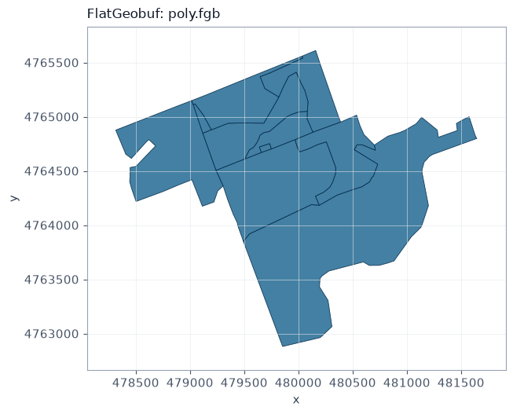

```python
# Read polygons from a FlatGeobuf sample
read_vector("testfgb/poly.fgb", title="FlatGeobuf: poly.fgb")  # Open FlatGeobuf polygons
```

### OpenStreetMap

OSM XML (`.osm`) is what the openstreetmap.org export button and the Overpass API return for a small area. Protocolbuffer Binary Format (`.osm.pbf`) is the country and state extract from Geofabrik and BBBike. GDAL's OSM driver splits a file into `points`, `lines`, `multilinestrings`, `multipolygons`, and `other_relations`. Feature counts stay empty until the file is scanned, which is normal for this driver.

`osm/test.osm` is a tiny hand-written extract. `osm/two_points.pbf` is the same kind of data in PBF.

```python
# List layers inside the OSM XML sample
list_layers("osm/test.osm")  # Show OSM XML layer names available to GDAL
```

```
OpenStreetMap  |  driver OSM  |  osm/test.osm
```

|  | layer | geometry_type | features | crs | fields |
| --- | --- | --- | --- | --- | --- |
| 0 | points | Point | None | EPSG:4326 | 10 |
| 1 | lines | Line String | None | EPSG:4326 | 10 |
| 2 | multilinestrings | Multi Line String | None | EPSG:4326 | 4 |
| 3 | multipolygons | Multi Polygon | None | EPSG:4326 | 25 |
| 4 | other_relations | Geometry Collection | None | EPSG:4326 | 4 |

```
File:             osm/test.osm
Format:           OpenStreetMap
Driver:           OSM
Layer count:      5
Layer names:      ['points', 'lines', 'multilinestrings', 'multipolygons', 'other_relations']
Active layer:     multipolygons
Geometry type:    Multi Polygon
Geometry source:  layer
Feature count:    None
Features read:    3
CRS:              EPSG:4326
Bounds:           (2.0, 49.0, 3.0, 50.0)
Fields:
  - osm_id (String)
  - osm_way_id (String)
  - name (String)
  - type (String)
  - aeroway (String)
  - amenity (String)
  - admin_level (String)
  - barrier (String)
  - boundary (String)
  - building (String)
  - craft (String)
  - geological (String)
  - historic (String)
  - land_area (String)
  - landuse (String)
  - leisure (String)
  - man_made (String)
  - military (String)
  - natural (String)
  - office (String)
  - place (String)
  - shop (String)
  - sport (String)
  - tourism (String)
  - other_tags (String)
```

|  | fid | geom_type | osm_id | osm_way_id | name | type | aeroway | amenity |
| --- | --- | --- | --- | --- | --- | --- | --- | --- |
| 0 | 1 | MultiPolygon | 1 | NaN | NaN | multipolygon | None | None |
| 1 | 5 | MultiPolygon | 5 | NaN | NaN | multipolygon | None | None |
| 2 | 8 | MultiPolygon | NaN | 8 | standalone_polygon | NaN | None | None |

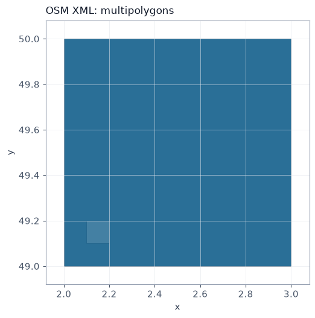

```python
# Read multipolygons from the OSM XML sample
read_vector("osm/test.osm", layer="multipolygons", title="OSM XML: multipolygons")  # Open OSM multipolygons
```

```
File:             osm/test.osm
Format:           OpenStreetMap
Driver:           OSM
Layer count:      5
Layer names:      ['points', 'lines', 'multilinestrings', 'multipolygons', 'other_relations']
Active layer:     lines
Geometry type:    Line String
Geometry source:  layer
Feature count:    None
Features read:    2
CRS:              EPSG:4326
Bounds:           (2.0, 49.0, 3.0, 50.0)
Fields:
  - osm_id (String)
  - name (String)
  - highway (String)
  - waterway (String)
  - aerialway (String)
  - barrier (String)
  - man_made (String)
  - railway (String)
  - z_order (Integer)
  - other_tags (String)
```

|  | fid | geom_type | osm_id | name | highway | waterway | aerialway | barrier |
| --- | --- | --- | --- | --- | --- | --- | --- | --- |
| 0 | 1 | LineString | 1 | NaN | motorway | None | None | None |
| 1 | 6 | LineString | 6 | id_6 | NaN | None | None | None |

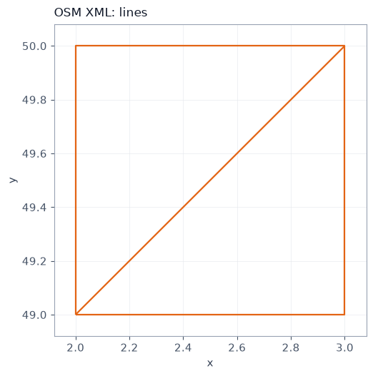

```python
# Read lines from the OSM XML sample
read_vector("osm/test.osm", layer="lines", title="OSM XML: lines")  # Open OSM lines
```

```
File:             osm/two_points.pbf
Format:           OpenStreetMap
Driver:           OSM
Layer count:      5
Layer names:      ['points', 'lines', 'multilinestrings', 'multipolygons', 'other_relations']
Active layer:     points
Geometry type:    Point
Geometry source:  layer
Feature count:    None
Features read:    2
CRS:              EPSG:4326
Bounds:           (2.0, 49.0, 2.0, 49.1)
Fields:
  - osm_id (String)
  - name (String)
  - barrier (String)
  - highway (String)
  - ref (String)
  - address (String)
  - is_in (String)
  - place (String)
  - man_made (String)
  - other_tags (String)
```

|  | fid | geom_type | osm_id | name | barrier | highway | ref | address |
| --- | --- | --- | --- | --- | --- | --- | --- | --- |
| 0 | 1 | Point | 1 | None | None | None | None | None |
| 1 | 2 | Point | 2 | None | None | None | None | None |

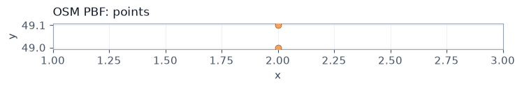

```python
# Read points from the OSM PBF sample
read_vector("osm/two_points.pbf", layer="points", title="OSM PBF: points")  # Open OSM PBF points
```

# Part 2: Reading cloud-native layouts

### Cloud-native layouts

`open_cloud_native_vector_data` covers files that are meant to be read in pieces from object storage, plus the lakehouse tables and GeoParquet profiles built on the same idea. `read_cloud` prints the format, the schema profile when one is detected, the reader that did the work, and how a spatial lookup is served.

`supported_cloud_native_formats()` is the catalog. `available` is true when the reader this environment needs is installed. FlatGeobuf, PMTiles, GeoPackage, COPC, and GeoJSON Sequence run with the packages already used above. GeoParquet and GeoArrow need PyArrow. Lance and TileDB stay unavailable until those libraries are installed; the catalog still lists them.

```python
# Create a temp folder and display supported cloud-native vector formats
CLOUD = Path(tempfile.mkdtemp(prefix="geolattice_cloud_"))  # Working directory for cloud-native demos
print(f"Cloud-native examples: {CLOUD}")  # Show where demo files will be written

cloud_catalog = pd.DataFrame(supported_cloud_native_formats())  # Catalog of cloud-native readers
cloud_catalog["extensions"] = cloud_catalog["extensions"].map(lambda names: ", ".join(names))  # Join extensions
display(
    # Statement
    cloud_catalog[
        ["name", "family", "extensions", "spatial_access", "available"]  # Columns to show
    ].rename(columns={"name": "format", "spatial_access": "spatial access"})  # Friendlier headers
)
```

```
Cloud-native examples: /tmp/geolattice_cloud_gmr_la8r
```

|  | format | family | extensions | spatial access | available |
| --- | --- | --- | --- | --- | --- |
| 0 | GeoParquet | cloud-native | .parquet, .geoparquet | columnar | True |
| 1 | GeoArrow | cloud-native | .arrow, .arrows, .feather, .ipc | columnar | True |
| 2 | FlatGeobuf | cloud-native | .fgb | http-range | True |
| 3 | PMTiles | cloud-native | .pmtiles | http-range | True |
| 4 | GeoPackage | cloud-native | .gpkg | sqlite | True |
| 5 | COPC | cloud-native | .copc.laz, .copc.las | http-range | True |
| 6 | Apache Iceberg | table |  | lakehouse | True |
| 7 | Delta Lake | table |  | lakehouse | True |
| 8 | Parquet GEOMETRY/GEOGRAPHY | table | .parquet | columnar | True |
| 9 | fiboa | specification | .parquet, .geoparquet | columnar | True |
| 10 | stac-geoparquet | specification | .parquet, .geoparquet | columnar | True |
| 11 | Overture Maps | specification | .parquet, .geoparquet | columnar | True |
| 12 | GeoJSON Sequence | other | .geojsonl, .geojsons, .ndjson, .jsonl | stream | True |
| 13 | H3 / S2 cell index | other | .parquet, .arrow, .feather | cell-index | True |
| 14 | TileDB | other |  | array | False |
| 15 | Lance | other | .lance | columnar | False |

### GeoParquet

GeoParquet stores features in a Parquet file and records the geometry column, encoding, bounding box, and CRS in a `geo` metadata key. A query can read a few columns instead of every attribute. fiboa, stac-geoparquet, and Overture Maps are schemas on top of that file: `format_name` stays GeoParquet and `schema_name` names the profile.

The cities file below is filtered twice: once with `where` on `population`, and once with a bounding box that also keeps only the `name` column. A `where` term has to name a column that is still loaded, so the attribute filter and the column projection are separate calls.

A binary geometry column without the `geo` key is still decoded as WKB, with a warning that the GeoParquet metadata is missing. A Parquet file that uses the 2025 GEOMETRY or GEOGRAPHY logical type, and has no `geo` key, is reported as Parquet GEOMETRY / GEOGRAPHY instead.

```
========================================================================
GeoParquet: cities
========================================================================
File:              /tmp/geolattice_cloud_gmr_la8r/cities.parquet
Format:            GeoParquet (geoparquet)
Schema:            n/a
Reader:            pyarrow
Spatial access:    columnar
Spatial index:     geoparquet
Geometry encoding: WKB
Layers:            1
Active layer:      cities
Features:          3
CRS:               EPSG:4326
Extent:            (0.0, 1.0, 4.0, 5.0)
Fields:
  - name (string)
  - population (int64)
```

|  | fid | geom_type | name | population |
| --- | --- | --- | --- | --- |
| 0 | 0 | Point | alpha | 10 |
| 1 | 1 | Point | beta | 20 |
| 2 | 2 | Point | gamma | 30 |

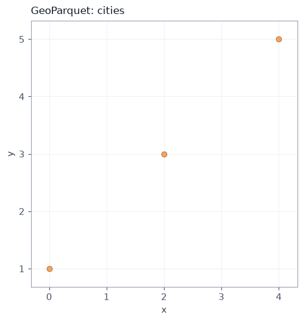

```
========================================================================
GeoParquet: population = 10
========================================================================
File:              /tmp/geolattice_cloud_gmr_la8r/cities.parquet
Format:            GeoParquet (geoparquet)
Schema:            n/a
Reader:            pyarrow
Spatial access:    columnar
Spatial index:     geoparquet
Geometry encoding: WKB
Layers:            1
Active layer:      cities
Features:          3
CRS:               EPSG:4326
Extent:            (0.0, 1.0, 4.0, 5.0)
Fields:
  - name (string)
  - population (int64)
Filtered rows:     1
```

|  | fid | geom_type | name | population |
| --- | --- | --- | --- | --- |
| 0 | 0 | Point | alpha | 10 |

```
========================================================================
GeoParquet: name column inside the bbox
========================================================================
File:              /tmp/geolattice_cloud_gmr_la8r/cities.parquet
Format:            GeoParquet (geoparquet)
Schema:            n/a
Reader:            pyarrow
Spatial access:    columnar
Spatial index:     geoparquet
Geometry encoding: WKB
Layers:            1
Active layer:      cities
Features:          3
CRS:               EPSG:4326
Extent:            (0.0, 1.0, 4.0, 5.0)
Fields:
  - name (string)
  - population (int64)
Filtered rows:     2
```

|  | fid | geom_type | name |
| --- | --- | --- | --- |
| 0 | 0 | Point | alpha |
| 1 | 1 | Point | beta |

```
========================================================================
fiboa: field boundaries
========================================================================
File:              /tmp/geolattice_cloud_gmr_la8r/fields.parquet
Format:            GeoParquet (geoparquet)
Schema:            fiboa
Reader:            pyarrow
Spatial access:    columnar
Spatial index:     geoparquet
Geometry encoding: WKB
Layers:            1
Active layer:      fields
Features:          1
CRS:               EPSG:4326
Extent:            (10.0, 20.0, 10.0, 20.0)
Fields:
  - id (string)
  - area (double)
  - determination_datetime (string)
```

|  | fid | geom_type | id | area | determination_datetime |
| --- | --- | --- | --- | --- | --- |
| 0 | 0 | Point | field-1 | 10.5 | 2024-01-01T00:00:00Z |

```
========================================================================
stac-geoparquet: item footprints
========================================================================
File:              /tmp/geolattice_cloud_gmr_la8r/items.parquet
Format:            GeoParquet (geoparquet)
Schema:            stac-geoparquet
Reader:            pyarrow
Spatial access:    columnar
Spatial index:     geoparquet
Geometry encoding: WKB
Layers:            1
Active layer:      items
Features:          1
CRS:               EPSG:4326
Extent:            (-10.0, 35.0, -10.0, 35.0)
Fields:
  - id (string)
  - datetime (string)
  - assets (struct<visual: struct<href: string>>)
```

|  | fid | geom_type | id | datetime | assets |
| --- | --- | --- | --- | --- | --- |
| 0 | 0 | Point | scene-1 | 2024-06-01T00:00:00Z | {'visual': {'href': 'https://example.com/a.t... |

```
========================================================================
Overture Maps: buildings
========================================================================
File:              /tmp/geolattice_cloud_gmr_la8r/buildings.parquet
Format:            GeoParquet (geoparquet)
Schema:            overture
Reader:            pyarrow
Spatial access:    columnar
Spatial index:     geoparquet
Geometry encoding: WKB
Layers:            1
Active layer:      buildings
Features:          1
CRS:               EPSG:4326
Extent:            (12.0, 48.0, 12.0, 48.0)
Fields:
  - id (string)
  - theme (string)
  - type (string)
  - names (struct<primary: string>)
```

|  | fid | geom_type | id | theme | type | names |
| --- | --- | --- | --- | --- | --- | --- |
| 0 | 0 | Point | bld-1 | buildings | building | {'primary': 'Library'} |

```python
# Helpers and demos for writing/reading GeoParquet and related cloud formats
import json

# Statement
import pyarrow as pa
# Statement
import pyarrow.parquet as pq
# Statement
from shapely.geometry import Point
# Statement
from shapely.wkb import dumps as dump_wkb


# Define write_geoparquet()
def write_geoparquet(path, columns, geo=None, metadata=None):
    # Set arrays
    arrays = []
    # Set fields
    fields = []
    # Loop: name, values in columns.items()
    for name, values in columns.items():
        # If isinstance(values[0], (bytes, bytearray))
        if isinstance(values[0], (bytes, bytearray)):
            # Set arrays.append(pa.array(values, type
            arrays.append(pa.array(values, type=pa.binary()))
            # Call append()
            fields.append(pa.field(name, pa.binary()))
        # Otherwise
        else:
            # Call append()
            arrays.append(pa.array(values))
            # Call append()
            fields.append(pa.field(name, arrays[-1].type))
    # Set file_meta
    file_meta = {}
    # If geo is not None
    if geo is not None:
        # Set file_meta[b"geo"]
        file_meta[b"geo"] = json.dumps(geo).encode("utf-8")
    # If metadata
    if metadata:
        # Loop: key, value in metadata.items()
        for key, value in metadata.items():
            # Set file_meta[key.encode("utf-8")]
            file_meta[key.encode("utf-8")] = value.encode("utf-8")
    # Set schema
    schema = pa.schema(fields, metadata=file_meta or None)
    # Set pq.write_table(pa.table(dict(zip(columns, arrays)), schema
    pq.write_table(pa.table(dict(zip(columns, arrays)), schema=schema), path)


# Define point_geo()
def point_geo(xs, ys):
    # Return result
    return {
        # Include version": "1.1.0
        "version": "1.1.0",
        # Include primary_column": "geometry
        "primary_column": "geometry",
        # Statement
        "columns": {
            # Statement
            "geometry": {
                # Include encoding": "WKB
                "encoding": "WKB",
                # Statement
                "geometry_types": ["Point"],
                # Call "bbox": [min()
                "bbox": [min(xs), min(ys), max(xs), max(ys)],
                # Statement
                "crs": {"id": {"authority": "EPSG", "code": 4326}},
            # Close mapping or set
            }
        # Statement
        },
    # Close mapping or set
    }


# Set xs
xs = [0.0, 2.0, 4.0]
# Set ys
ys = [1.0, 3.0, 5.0]
# Call write_geoparquet()
write_geoparquet(
    # Statement
    CLOUD / "cities.parquet",
    # Statement
    {
        # Statement
        "name": ["alpha", "beta", "gamma"],
        # Statement
        "population": [10, 20, 30],
        # Call "geometry": [dump_wkb()
        "geometry": [dump_wkb(Point(x, y)) for x, y in zip(xs, ys)],
    # Statement
    },
    # Set geo
    geo=point_geo(xs, ys),
# Close multi-line expression
)
# Set read_cloud(CLOUD / "cities.parquet", title
read_cloud(CLOUD / "cities.parquet", title="GeoParquet: cities")
# Call read_cloud()
read_cloud(
    # Statement
    CLOUD / "cities.parquet",
    # Set title
    title="GeoParquet: population = 10",
    # Set plot
    plot=False,
    # Set where
    where="population = 10",
# Close multi-line expression
)
# Call read_cloud()
read_cloud(
    # Statement
    CLOUD / "cities.parquet",
    # Set title
    title="GeoParquet: name column inside the bbox",
    # Set plot
    plot=False,
    # Set bbox
    bbox=(-0.1, 0, 3, 4),
    # Set columns
    columns=["name"],
# Close multi-line expression
)

# Call write_geoparquet()
write_geoparquet(
    # Statement
    CLOUD / "fields.parquet",
    # Statement
    {
        # Statement
        "id": ["field-1"],
        # Statement
        "area": [10.5],
        # Statement
        "determination_datetime": ["2024-01-01T00:00:00Z"],
        # Call "geometry": [dump_wkb()
        "geometry": [dump_wkb(Point(10, 20))],
    # Statement
    },
    # Set metadata
    metadata={"fiboa": "1.0.0"},
    # Set geo
    geo=point_geo([10], [20]),
# Close multi-line expression
)
# Set read_cloud(CLOUD / "fields.parquet", title
read_cloud(CLOUD / "fields.parquet", title="fiboa: field boundaries", plot=False)

# Call write_geoparquet()
write_geoparquet(
    # Statement
    CLOUD / "items.parquet",
    # Statement
    {
        # Statement
        "id": ["scene-1"],
        # Statement
        "datetime": ["2024-06-01T00:00:00Z"],
        # Statement
        "assets": [{"visual": {"href": "https://example.com/a.tif"}}],
        # Call "geometry": [dump_wkb()
        "geometry": [dump_wkb(Point(-10, 35))],
    # Statement
    },
    # Set geo
    geo=point_geo([-10], [35]),
# Close multi-line expression
)
# Set read_cloud(CLOUD / "items.parquet", title
read_cloud(CLOUD / "items.parquet", title="stac-geoparquet: item footprints", plot=False)

# Call write_geoparquet()
write_geoparquet(
    # Statement
    CLOUD / "buildings.parquet",
    # Statement
    {
        # Statement
        "id": ["bld-1"],
        # Statement
        "theme": ["buildings"],
        # Statement
        "type": ["building"],
        # Statement
        "names": [{"primary": "Library"}],
        # Call "geometry": [dump_wkb()
        "geometry": [dump_wkb(Point(12, 48))],
    # Statement
    },
    # Set metadata
    metadata={"dataset": "Overture Maps buildings"},
    # Set geo
    geo=point_geo([12], [48]),
# Close multi-line expression
)
# Set read_cloud(CLOUD / "buildings.parquet", title
read_cloud(CLOUD / "buildings.parquet", title="Overture Maps: buildings", plot=False)
```

### GeoArrow

GeoArrow is the in-memory form of the same geometry. On disk it is an Arrow IPC or Feather file whose geometry column carries an Arrow extension name such as `geoarrow.wkb`. Tools that already speak Arrow can pass the column without converting it to GeoJSON.

```
========================================================================
GeoArrow: Feather WKB
========================================================================
File:              /tmp/geolattice_cloud_gmr_la8r/sites.feather
Format:            GeoArrow (geoarrow)
Schema:            n/a
Reader:            pyarrow
Spatial access:    columnar
Spatial index:     n/a
Geometry encoding: geoarrow.wkb
Layers:            1
Active layer:      sites
Features:          2
CRS:               EPSG:4326
Extent:            (1.0, 2.0, 8.0, 9.0)
Fields:
  - name (string)
```

|  | fid | geom_type | name |
| --- | --- | --- | --- |
| 0 | 0 | Point | alpha |
| 1 | 1 | Point | beta |

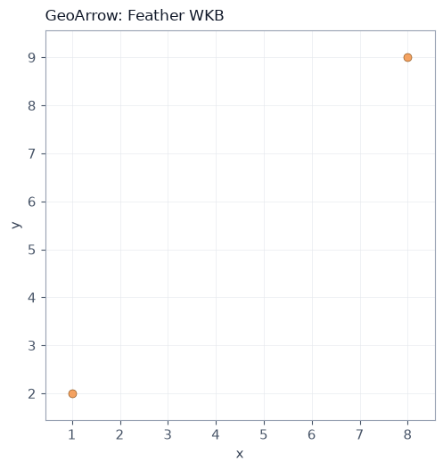

```python
# Read a GeoParquet / cloud-native sample written above
import pyarrow.feather as feather

# Set arrow_schema
arrow_schema = pa.schema(
    # Statement
    [
        # Call field()
        pa.field("name", pa.string()),
        # Set pa.field("geometry", pa.binary(), metadata
        pa.field("geometry", pa.binary(), metadata={b"ARROW:extension:name": b"geoarrow.wkb"}),
    # Close multi-line expression
    ]
# Close multi-line expression
)
# Set arrow_table
arrow_table = pa.table(
    # Call {"name": ["alpha", "beta"], "geometry": [dump_wkb()
    {"name": ["alpha", "beta"], "geometry": [dump_wkb(Point(8, 9)), dump_wkb(Point(1, 2))]},
    # Set schema
    schema=arrow_schema,
# Close multi-line expression
)
# Call write_feather()
feather.write_feather(arrow_table, CLOUD / "sites.feather")
# Set read_cloud(CLOUD / "sites.feather", title
read_cloud(CLOUD / "sites.feather", title="GeoArrow: Feather WKB")
```

### FlatGeobuf range requests

The desktop section opened `testfgb/poly.fgb` through GDAL. The cloud-native reader uses the same driver and reports the packed Hilbert R-tree, which is what a remote `.fgb` uses for an HTTP range request. The bounding box below covers the north-east part of the sample, so the table is a subset of the ten polygons.

```
========================================================================
FlatGeobuf: north-east bbox
========================================================================
File:              testfgb/poly.fgb
Format:            FlatGeobuf (flatgeobuf)
Schema:            n/a
Reader:            gdal
Spatial access:    http-range
Spatial index:     hilbert-rtree
Geometry encoding: flatgeobuf
Layers:            1
Active layer:      poly
Features:          10
CRS:               EPSG:27700
Extent:            (478315.53125, 4762880.5, 481645.3125, 4765610.5)
Fields:
  - AREA (Real)
  - EAS_ID (Integer64)
  - PRFEDEA (String)
Filtered rows:     8
```

|  | fid | geom_type | AREA | EAS_ID | PRFEDEA |
| --- | --- | --- | --- | --- | --- |
| 0 | 0 | Polygon | 1634833.375 | 158 | 35043369 |
| 1 | 1 | Polygon | 215229.266 | 168 | 35043411 |
| 2 | 2 | Polygon | 268597.625 | 166 | 35043409 |
| 3 | 3 | Polygon | 596610.313 | 165 | 35043408 |
| 4 | 4 | Polygon | 5268.813 | 170 | 35043413 |

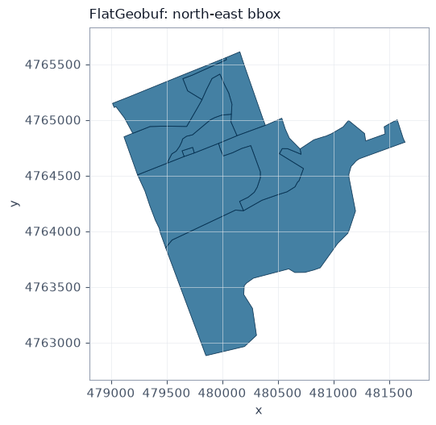

```python
# Read another cloud-native sample
read_cloud(
    # Include testfgb/poly.fgb
    "testfgb/poly.fgb",
    # Set title
    title="FlatGeobuf: north-east bbox",
    # Set bbox
    bbox=(479600, 4764500, 481700, 4765700),
# Close multi-line expression
)
```

### PMTiles

A PMTiles archive is one file of map tiles. A static host or an S3 bucket can serve it with HTTP range requests, which replaces a tile server. The tiles are for display. `read_tile(z, x, y)` returns the bytes of one tile. When the archive holds Mapbox Vector Tiles, the same file also yields features through GDAL.

```
========================================================================
PMTiles: places
========================================================================
File:              /tmp/geolattice_cloud_gmr_la8r/places.pmtiles
Format:            PMTiles (pmtiles)
Schema:            n/a
Reader:            pmtiles+gdal
Spatial access:    http-range
Spatial index:     hilbert
Geometry encoding: mvt
Layers:            1
Active layer:      places
Features:          2
CRS:               EPSG:3857
Extent:            (1113194.9079327357, 2273030.926987689, 1335833.8895192828, 2511525.234845713)
Fields:
  - mvt_id (Integer64)
  - name (String)
```

|  | fid | geom_type | mvt_id | name |
| --- | --- | --- | --- | --- |
| 0 | 6 | MultiPoint | None | alpha |
| 1 | 22 | MultiPoint | None | beta |

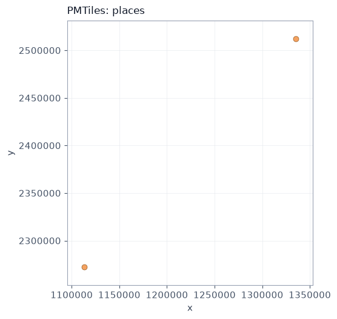

```
Tile 0/0/0: 68 bytes, gzip=False
Vector layer: places
```

```python
# Build and read additional cloud-native examples
from osgeo import ogr, osr

# Set pmtiles_path
pmtiles_path = CLOUD / "places.pmtiles"
# Set pmtiles_srs
pmtiles_srs = osr.SpatialReference()
# Call ImportFromEPSG()
pmtiles_srs.ImportFromEPSG(4326)
# Call SetAxisMappingStrategy()
pmtiles_srs.SetAxisMappingStrategy(osr.OAMS_TRADITIONAL_GIS_ORDER)
# Set pmtiles_ds
pmtiles_ds = ogr.GetDriverByName("PMTiles").CreateDataSource(str(pmtiles_path))
# Set pmtiles_layer
pmtiles_layer = pmtiles_ds.CreateLayer(
    # Set "places", pmtiles_srs, ogr.wkbPoint, options
    "places", pmtiles_srs, ogr.wkbPoint, options=["MINZOOM=0", "MAXZOOM=2"]
# Close multi-line expression
)
# Call CreateField()
pmtiles_layer.CreateField(ogr.FieldDefn("name", ogr.OFTString))
# Loop: label, x_coord, y_coord in (("alpha", 10.0, 20.0), ("be
for label, x_coord, y_coord in (("alpha", 10.0, 20.0), ("beta", 12.0, 22.0)):
    # Set feature
    feature = ogr.Feature(pmtiles_layer.GetLayerDefn())
    # Call SetField()
    feature.SetField("name", label)
    # Set geometry
    geometry = ogr.Geometry(ogr.wkbPoint)
    # Call AddPoint_2D()
    geometry.AddPoint_2D(x_coord, y_coord)
    # Call SetGeometry()
    feature.SetGeometry(geometry)
    # Call CreateFeature()
    pmtiles_layer.CreateFeature(feature)
# Set pmtiles_layer
pmtiles_layer = None
# Set pmtiles_ds
pmtiles_ds = None

# Set read_cloud(pmtiles_path, title
read_cloud(pmtiles_path, title="PMTiles: places")
# With open_cloud_native_vector_data(pmtiles_path) as dataset
with open_cloud_native_vector_data(pmtiles_path) as dataset:
    # Set tile
    tile = dataset.read_tile(0, 0, 0)
    # Set gzip_tile
    gzip_tile = tile.startswith(bytes([0x1F, 0x8B]))
    # Set print(f"Tile 0/0/0: {len(tile)} bytes, gzip
    print(f"Tile 0/0/0: {len(tile)} bytes, gzip={gzip_tile}")
    # Call print()
    print("Vector layer:", dataset.details["metadata"]["vector_layers"][0]["id"])
```

### GeoPackage

GeoPackage is a SQLite database and the usual replacement for a shapefile. It is not cloud-native: a client generally downloads the file before reading it. GDAL can still open a remote `.gpkg`, and the cloud-native reader uses that driver so the call looks the same as GeoParquet or FlatGeobuf.

```
========================================================================
GeoPackage: sites
========================================================================
File:              /tmp/geolattice_cloud_gmr_la8r/sites.gpkg
Format:            GeoPackage (geopackage)
Schema:            n/a
Reader:            gdal
Spatial access:    sqlite
Spatial index:     rtree
Geometry encoding: gpkg
Layers:            1
Active layer:      sites
Features:          2
CRS:               EPSG:4326
Extent:            (1.0, 2.0, 3.0, 4.0)
Fields:
  - name (String)
```

|  | fid | geom_type | name |
| --- | --- | --- | --- |
| 0 | 1 | Point | alpha |
| 1 | 2 | Point | beta |

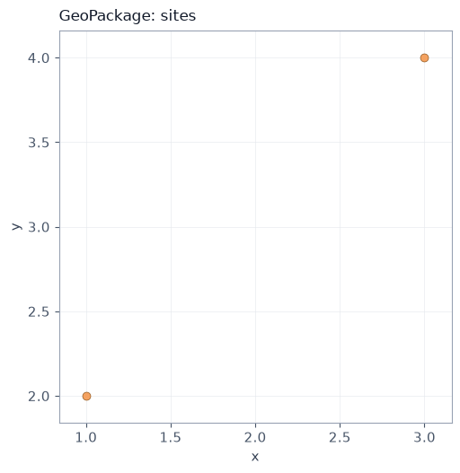

```python
# Read a cloud-native dataset with spatial access metadata
gpkg_path = CLOUD / "sites.gpkg"
# Set gpkg_srs
gpkg_srs = osr.SpatialReference()
# Call ImportFromEPSG()
gpkg_srs.ImportFromEPSG(4326)
# Call SetAxisMappingStrategy()
gpkg_srs.SetAxisMappingStrategy(osr.OAMS_TRADITIONAL_GIS_ORDER)
# Set gpkg_ds
gpkg_ds = ogr.GetDriverByName("GPKG").CreateDataSource(str(gpkg_path))
# Set gpkg_layer
gpkg_layer = gpkg_ds.CreateLayer("sites", gpkg_srs, ogr.wkbPoint)
# Call CreateField()
gpkg_layer.CreateField(ogr.FieldDefn("name", ogr.OFTString))
# Loop: label, x_coord, y_coord in (("alpha", 1.0, 2.0), ("beta
for label, x_coord, y_coord in (("alpha", 1.0, 2.0), ("beta", 3.0, 4.0)):
    # Set feature
    feature = ogr.Feature(gpkg_layer.GetLayerDefn())
    # Call SetField()
    feature.SetField("name", label)
    # Set geometry
    geometry = ogr.Geometry(ogr.wkbPoint)
    # Call AddPoint_2D()
    geometry.AddPoint_2D(x_coord, y_coord)
    # Call SetGeometry()
    feature.SetGeometry(geometry)
    # Call CreateFeature()
    gpkg_layer.CreateFeature(feature)
# Set gpkg_layer
gpkg_layer = None
# Set gpkg_ds
gpkg_ds = None
# Set read_cloud(gpkg_path, layer
read_cloud(gpkg_path, layer="sites", title="GeoPackage: sites")
```

### COPC

Cloud Optimized Point Cloud is a LAZ file whose header carries an octree. A client range-requests the voxels inside a bounding box instead of downloading the file. This example is an uncompressed point-format 6 file with one root voxel, so it can be read without a LAZ decompressor. A compressed `.copc.laz` needs `laspy` and `lazrs`; the header and hierarchy are still readable without them.

```
========================================================================
COPC: two points
========================================================================
File:              /tmp/geolattice_cloud_gmr_la8r/cloud.copc.laz
Format:            COPC (copc)
Schema:            n/a
Reader:            copc
Spatial access:    http-range
Spatial index:     octree
Geometry encoding: copc
Layers:            1
Active layer:      points
Features:          2
CRS:               GEOGCS["WGS 84",DATUM["WGS_1984",SPHEROID["WGS 84",6378137,298.257223563]],PRIMEM["Greenwich",0],UNIT["degree",0.0174532925199433],AUTHORITY["EPSG","4326"]]
Extent:            (1.0, 2.0, 4.0, 6.0)
Fields:
  - x (Real)
  - y (Real)
  - z (Real)
Filtered rows:     1
```

|  | fid | geom_type | x | y | z |
| --- | --- | --- | --- | --- | --- |
| 0 | 0 | Point | 1.0 | 2.0 | 3.0 |

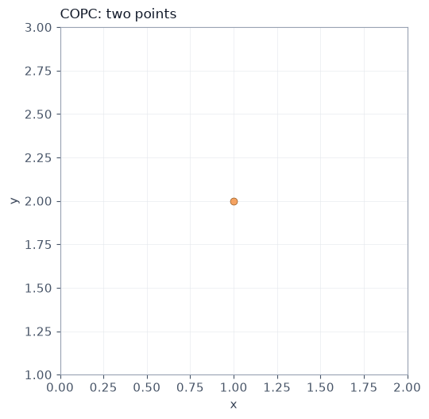

```
Octree nodes: 1
Spacing: 1.0
```

```python
# Build a minimal LAS point file and open it as cloud-native data
import struct

# Set copc_path
copc_path = CLOUD / "cloud.copc.laz"
# Set points
points = [(1.0, 2.0, 3.0), (4.0, 6.0, 8.0)]
# Set wkt
wkt = (
    # Statement
    'GEOGCS["WGS 84",DATUM["WGS_1984",SPHEROID["WGS 84",6378137,298.257223563]],'
    # Statement
    'PRIMEM["Greenwich",0],UNIT["degree",0.0174532925199433],AUTHORITY["EPSG","4326"]]'
# Call encode()
).encode("ascii") + b"\x00"
# Set scale
scale = 0.001
# Set point_blob
point_blob = bytearray()
# Loop: x_coord, y_coord, z_coord in points
for x_coord, y_coord, z_coord in points:
    # Call extend()
    point_blob.extend(
        # Call pack()
        struct.pack(
            # Include <3iHBBBBhHd
            "<3iHBBBBhHd",
            # Call int()
            int(round(x_coord / scale)),
            # Call int()
            int(round(y_coord / scale)),
            # Call int()
            int(round(z_coord / scale)),
            # Statement
            0, 0, 0, 0, 0, 0, 0, 0.0,
        # Close multi-line expression
        )
    # Close multi-line expression
    )
# Set info_payload
info_payload = struct.pack("<5dQQ2d11d", 0.0, 0.0, 0.0, 50.0, 1.0, 0, 32, 0.0, 0.0, *([0.0] * 11))
# Set vlr_copc
vlr_copc = bytearray(54 + len(info_payload))
# Set vlr_copc[2:6]
vlr_copc[2:6] = b"copc"
# Call pack_into()
struct.pack_into("<HH", vlr_copc, 18, 1, len(info_payload))
# Set vlr_copc[54:]
vlr_copc[54:] = info_payload
# Set vlr_wkt
vlr_wkt = bytearray(54 + len(wkt))
# Set vlr_wkt[2:18]
vlr_wkt[2:18] = b"LASF_Projection"
# Call pack_into()
struct.pack_into("<HH", vlr_wkt, 18, 2112, len(wkt))
# Set vlr_wkt[54:]
vlr_wkt[54:] = wkt
# Set offset_points
offset_points = 375 + len(vlr_copc) + len(vlr_wkt)
# Set hier_offset
hier_offset = offset_points + len(point_blob)
# Call pack_into()
struct.pack_into("<Q", vlr_copc, 54 + 40, hier_offset)
# Call pack_into()
struct.pack_into("<Q", vlr_copc, 54 + 48, 32)
# Set xs, ys, zs
xs, ys, zs = zip(*points)
# Set header
header = bytearray(375)
# Set header[0:4]
header[0:4] = b"LASF"
# Set header[24]
header[24] = 1
# Set header[25]
header[25] = 4
# Call pack_into()
struct.pack_into("<H", header, 94, 375)
# Call pack_into()
struct.pack_into("<I", header, 96, offset_points)
# Call pack_into()
struct.pack_into("<I", header, 100, 2)
# Set header[104]
header[104] = 6
# Call pack_into()
struct.pack_into("<H", header, 105, 30)
# Call pack_into()
struct.pack_into("<3d", header, 131, scale, scale, scale)
# Call pack_into()
struct.pack_into("<6d", header, 179, max(xs), min(xs), max(ys), min(ys), max(zs), min(zs))
# Call pack_into()
struct.pack_into("<Q", header, 247, len(points))
# Set hierarchy
hierarchy = struct.pack("<4iQii", 0, 0, 0, 0, offset_points, len(point_blob), len(points))
# Call write_bytes()
copc_path.write_bytes(bytes(header) + bytes(vlr_copc) + bytes(vlr_wkt) + bytes(point_blob) + hierarchy)

# Call read_cloud()
read_cloud(
    # Statement
    copc_path,
    # Set title
    title="COPC: two points",
    # Set bbox
    bbox=(0, 0, 2, 3),
    # Set columns
    columns=["x", "y", "z"],
# Close multi-line expression
)
# With open_cloud_native_vector_data(copc_path) as dataset
with open_cloud_native_vector_data(copc_path) as dataset:
    # Call print()
    print("Octree nodes:", len(dataset.hierarchy))
    # Call print()
    print("Spacing:", dataset.copc["spacing"])
```

### Delta Lake and Apache Iceberg

Both are directories of Parquet files plus a transaction log. Iceberg v3 can declare a field as `geometry` or `geography`. Delta Lake has no geometry type, so the geometry column is WKB and the reader says so.

Without the `deltalake` or `pyiceberg` packages, these cells read a local table from the JSON log and the Parquet data files. A remote table needs the matching package.

```
========================================================================
Delta Lake: live file only
========================================================================
File:              /tmp/geolattice_cloud_gmr_la8r/places_delta
Format:            Delta Lake (delta)
Schema:            n/a
Reader:            delta-log
Spatial access:    lakehouse
Spatial index:     geoparquet
Geometry encoding: WKB
Layers:            1
Active layer:      places_delta
Features:          1
CRS:               EPSG:4326
Extent:            (9.0, 8.0, 9.0, 8.0)
Fields:
  - name (string)
Notes:
  - Delta Lake has no native geometry type. Geometry is decoded from WKB.
```

|  | fid | geom_type | name |
| --- | --- | --- | --- |
| 0 | 0 | Point | new |

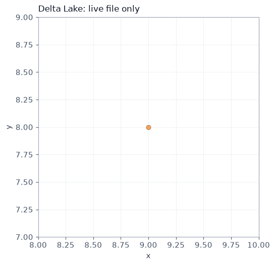

```
========================================================================
Apache Iceberg v3: geometry field
========================================================================
File:              /tmp/geolattice_cloud_gmr_la8r/places_iceberg
Format:            Apache Iceberg (iceberg)
Schema:            n/a
Reader:            iceberg-metadata
Spatial access:    lakehouse
Spatial index:     geoparquet
Geometry encoding: iceberg-geometry
Layers:            1
Active layer:      places_iceberg
Features:          1
CRS:               EPSG:4326
Extent:            (7.0, 11.0, 7.0, 11.0)
Fields:
  - name (string)
Notes:
  - Iceberg field 'geometry' is native type geometry. Binary values are decoded as WKB.
```

|  | fid | geom_type | name |
| --- | --- | --- | --- |
| 0 | 0 | Point | alpha |

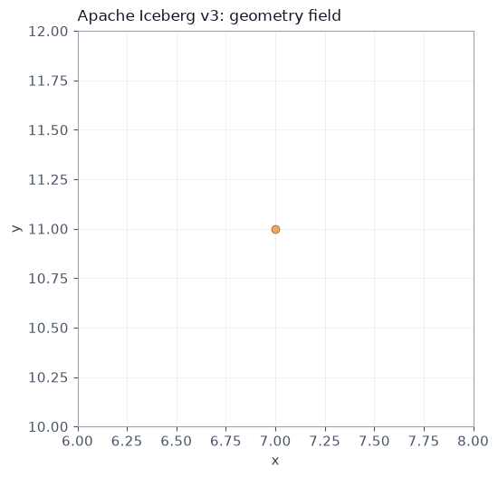

```python
# Build a tiny Delta Lake table of points and read the current version
delta_root = CLOUD / "places_delta"
# Call mkdir()
delta_root.mkdir()
# Call write_geoparquet()
write_geoparquet(delta_root / "part-000.parquet", {"name": ["old"], "geometry": [dump_wkb(Point(1, 1))]})
# Call write_geoparquet()
write_geoparquet(
    # Statement
    delta_root / "part-001.parquet",
    # Call {"name": ["new"], "geometry": [dump_wkb()
    {"name": ["new"], "geometry": [dump_wkb(Point(9, 8))]},
    # Set geo
    geo=point_geo([9], [8]),
# Close multi-line expression
)
# Set delta_schema
delta_schema = {
    # Include type": "struct
    "type": "struct",
    # Statement
    "fields": [
        # Statement
        {"name": "name", "type": "string", "nullable": True, "metadata": {}},
        # Statement
        {"name": "geometry", "type": "binary", "nullable": True, "metadata": {}},
    # Close multi-line expression
    ],
# Close mapping or set
}
# Set delta_log
delta_log = delta_root / "_delta_log"
# Call mkdir()
delta_log.mkdir()


# Define delta_commit()
def delta_commit(number, actions):
    # Set text
    text = "".join(json.dumps(action) + "\n" for action in actions)
    # Set (delta_log / f"{number:020d}.json").write_text(text, encoding
    (delta_log / f"{number:020d}.json").write_text(text, encoding="utf-8")


# Call delta_commit()
delta_commit(
    # Statement
    0,
    # Statement
    [
        # Statement
        {"protocol": {"minReaderVersion": 1, "minWriterVersion": 2}},
        # Statement
        {
            # Statement
            "metaData": {
                # Include id": "places
                "id": "places",
                # Statement
                "format": {"provider": "parquet", "options": {}},
                # Call dumps()
                "schemaString": json.dumps(delta_schema),
                # Statement
                "partitionColumns": [],
                # Statement
                "configuration": {},
                # Statement
                "createdTime": 1,
            # Close mapping or set
            }
        # Statement
        },
        # Statement
        {
            # Statement
            "add": {
                # Include path": "part-000.parquet
                "path": "part-000.parquet",
                # Statement
                "partitionValues": {},
                # Statement
                "size": 1,
                # Statement
                "modificationTime": 1,
                # Statement
                "dataChange": True,
            # Close mapping or set
            }
        # Statement
        },
    # Close multi-line expression
    ],
# Close multi-line expression
)
# Call delta_commit()
delta_commit(
    # Statement
    1,
    # Statement
    [
        # Statement
        {"remove": {"path": "part-000.parquet", "deletionTimestamp": 2, "dataChange": True}},
        # Statement
        {
            # Statement
            "add": {
                # Include path": "part-001.parquet
                "path": "part-001.parquet",
                # Statement
                "partitionValues": {},
                # Statement
                "size": 1,
                # Statement
                "modificationTime": 2,
                # Statement
                "dataChange": True,
            # Close mapping or set
            }
        # Statement
        },
    # Close multi-line expression
    ],
# Close multi-line expression
)
# Set read_cloud(delta_root, title
read_cloud(delta_root, title="Delta Lake: live file only")

# Set iceberg_root
iceberg_root = CLOUD / "places_iceberg"
# Set (iceberg_root / "data").mkdir(parents
(iceberg_root / "data").mkdir(parents=True)
# Call function()
(iceberg_root / "metadata").mkdir()
# Call write_geoparquet()
write_geoparquet(
    # Statement
    iceberg_root / "data" / "00000.parquet",
    # Call {"name": ["alpha"], "geometry": [dump_wkb()
    {"name": ["alpha"], "geometry": [dump_wkb(Point(7, 11))]},
    # Set geo
    geo=point_geo([7], [11]),
# Close multi-line expression
)
# Set iceberg_metadata
iceberg_metadata = {
    # Statement
    "format-version": 3,
    # Include table-uuid": "00000000-0000-0000-0000-000000000001
    "table-uuid": "00000000-0000-0000-0000-000000000001",
    # Call "location": str()
    "location": str(iceberg_root),
    # Statement
    "current-schema-id": 0,
    # Statement
    "schemas": [
        # Statement
        {
            # Statement
            "schema-id": 0,
            # Include type": "struct
            "type": "struct",
            # Statement
            "fields": [
                # Statement
                {"id": 1, "name": "name", "required": False, "type": "string"},
                # Statement
                {"id": 2, "name": "geometry", "required": False, "type": "geometry"},
            # Close multi-line expression
            ],
        # Close mapping or set
        }
    # Close multi-line expression
    ],
    # Statement
    "current-snapshot-id": None,
    # Statement
    "snapshots": [],
# Close mapping or set
}
# Call function()
(iceberg_root / "metadata" / "v3.metadata.json").write_text(
    # Set json.dumps(iceberg_metadata), encoding
    json.dumps(iceberg_metadata), encoding="utf-8"
# Close multi-line expression
)
# Set read_cloud(iceberg_root, title
read_cloud(iceberg_root, title="Apache Iceberg v3: geometry field")
```

## GeoJSON Sequence

The desktop section opened `geojsonseq/test.geojsonl` with GDAL. The cloud-native reader streams the same newline-delimited file, including an RFC 8142 record separator when one is present, and applies `where` and `bbox` while it reads.

```python
# Filter a GeoJSON Sequence read with an attribute where-clause
read_cloud(
    "geojsonseq/test.geojsonl",  # GeoJSON Sequence sample under DATA (or CLOUD resolve)
    title="GeoJSON Sequence: foo = 'bar'",  # Plot/report title
    plot=False,  # Skip map drawing; table only
    where="foo = 'bar'",  # Attribute filter passed to the reader
)
```

```
========================================================================
GeoJSON Sequence: foo = 'bar'
========================================================================
File:              geojsonseq/test.geojsonl
Format:            GeoJSON Sequence (geojsonseq)
Schema:            n/a
Reader:            geojsonseq
Spatial access:    stream
Spatial index:     n/a
Geometry encoding: geojson
Layers:            1
Active layer:      test
Features:          2
CRS:               EPSG:4326
Extent:            (1.0, 2.0, 3.0, 4.0)
Fields:
  - foo (JSON)
Filtered rows:     1
```

|  | fid | geom_type | foo |
| --- | --- | --- | --- |
| 0 | 0 | Point | bar |

## H3 and S2 cell indexes

Some Parquet tables store an H3 or S2 cell id instead of a geometry. The reader recognizes column names such as `h3_index` and `s2_token`. The cell id stays in the attribute table. A polygon is built only when the `h3` or `s2sphere` package is installed.

```python
# Write a tiny H3 parquet table and read it as cloud-native data
write_geoparquet(
    CLOUD / "hex.parquet",  # Output Parquet path
    {"h3_index": ["8928308280fffff"], "count": [4]},  # H3 cell id and a count attribute
)
read_cloud(CLOUD / "hex.parquet", title="H3: cell id column", plot=False)  # Read back without plotting
```

```
========================================================================
H3: cell id column
========================================================================
File:              /tmp/geolattice_cloud_gmr_la8r/hex.parquet
Format:            H3 / S2 cell index (h3-s2)
Schema:            n/a
Reader:            pyarrow
Spatial access:    cell-index
Spatial index:     h3
Geometry encoding: h3
Layers:            1
Active layer:      hex
Features:          1
CRS:               None
Extent:            None
Fields:
  - h3_index (string)
  - count (int64)
Notes:
  - An H3 cell-id column is present. Install the h3 package to build cell polygons.
```

|  | fid | geom_type | h3_index | count |
| --- | --- | --- | --- | --- |
| 0 | 0 | None | 8928308280fffff | 4 |

### What was opened

The table collects every file this notebook opened so far, including the cloud-native examples. The `driver` column is the GDAL driver for desktop formats and the reader name (`pyarrow`, `gdal`, …) for cloud-native layouts.

```python
# Summarize all successful read RESULTS collected so far
summary = pd.DataFrame(RESULTS)  # Convert the RESULTS list into a table
display(summary)  # Show one row per successfully opened file
print(f"{len(summary)} files opened")  # Total successful reads
```

|  | file | format | driver | layer | features | crs | status |
| --- | --- | --- | --- | --- | --- | --- | --- |
| 0 | poly.shp | ESRI Shapefile | ESRI Shapefile | poly | 10 | EPSG:27700 | opened |
| 1 | geojson/grenada.geojson | GeoJSON | GeoJSON | grenada | 1 | EPSG:4326 | opened |
| 2 | geojsonseq/test.geojsonl | GeoJSON Sequence | GeoJSONSeq | test | 2 | EPSG:4326 | opened |
| 3 | kml/samples.kml | KML / KMZ | LIBKML | Google Campus | 4 | EPSG:4326 | opened |
| 4 | kml/samples.kml | KML / KMZ | LIBKML | Paths | 6 | EPSG:4326 | opened |
| 5 | /tmp/geolattice_kmz_sg0gshm5/placemark.kmz | KML / KMZ | LIBKML | placemark | 1 | EPSG:4326 | opened |
| 6 | gml/gnis_pop_110.gml | GML | GML | gnis_pop | 20 | EPSG:4326 | opened |
| 7 | gpx/test.gpx | GPX | GPX | tracks | 3 | EPSG:4326 | opened |
| 8 | gpx/test.gpx | GPX | GPX | waypoints | 2 | EPSG:4326 | opened |
| 9 | wkt.csv | Delimited text (CSV/TXT) | CSV | wkt | 3 | NaN | opened |
| 10 | mitab/all_geoms.tab | MapInfo TAB / MIF | MapInfo File | all_geoms | 16 | LOCAL_CS["Nonearth",UNIT["Meter",1],AXIS["Ea... | opened |
| 11 | mitab/small.mif | MapInfo TAB / MIF | MapInfo File | small | 2 | LOCAL_CS["Nonearth",UNIT["Meter",1],AXIS["Ea... | opened |
| 12 | mitab/small.mif | MapInfo TAB / MIF | MapInfo File | small | 2 | LOCAL_CS["Nonearth",UNIT["Meter",1],AXIS["Ea... | opened |
| 13 | dxf/assorted.dxf | AutoCAD DXF | DXF | entities | 22 | NaN | opened |
| 14 | cad/line_r2000.dwg | AutoCAD DWG | CAD | 0 | 1 | NaN | opened |
| 15 | dgn/smalltest.dgn | MicroStation DGN | DGN | elements | 4 | NaN | opened |
| 16 | openfilegdb/polygon_golden.gdb | ESRI File Geodatabase | OpenFileGDB | OGRGeoJSON | 1 | EPSG:4326 | opened |
| 17 | sqlite/poly_spatialite.sqlite | SpatiaLite / SQLite | SQLite | poly | 10 | NaN | opened |
| 18 | testfgb/poly.fgb | FlatGeobuf | FlatGeobuf | poly | 10 | EPSG:27700 | opened |
| 19 | osm/test.osm | OpenStreetMap | OSM | multipolygons | 3 | EPSG:4326 | opened |
| 20 | osm/test.osm | OpenStreetMap | OSM | lines | 2 | EPSG:4326 | opened |
| 21 | osm/two_points.pbf | OpenStreetMap | OSM | points | 2 | EPSG:4326 | opened |
| 22 | /tmp/geolattice_cloud_gmr_la8r/cities.parquet | GeoParquet | pyarrow | cities | 3 | EPSG:4326 | opened |
| 23 | /tmp/geolattice_cloud_gmr_la8r/cities.parquet | GeoParquet | pyarrow | cities | 3 | EPSG:4326 | opened |
| 24 | /tmp/geolattice_cloud_gmr_la8r/cities.parquet | GeoParquet | pyarrow | cities | 3 | EPSG:4326 | opened |
| 25 | /tmp/geolattice_cloud_gmr_la8r/fields.parquet | GeoParquet | pyarrow | fields | 1 | EPSG:4326 | opened |
| 26 | /tmp/geolattice_cloud_gmr_la8r/items.parquet | GeoParquet | pyarrow | items | 1 | EPSG:4326 | opened |
| 27 | /tmp/geolattice_cloud_gmr_la8r/buildings.parquet | GeoParquet | pyarrow | buildings | 1 | EPSG:4326 | opened |
| 28 | /tmp/geolattice_cloud_gmr_la8r/sites.feather | GeoArrow | pyarrow | sites | 2 | EPSG:4326 | opened |
| 29 | testfgb/poly.fgb | FlatGeobuf | gdal | poly | 10 | EPSG:27700 | opened |
| 30 | /tmp/geolattice_cloud_gmr_la8r/places.pmtiles | PMTiles | pmtiles+gdal | places | 2 | EPSG:3857 | opened |
| 31 | /tmp/geolattice_cloud_gmr_la8r/sites.gpkg | GeoPackage | gdal | sites | 2 | EPSG:4326 | opened |
| 32 | /tmp/geolattice_cloud_gmr_la8r/cloud.copc.laz | COPC | copc | points | 2 | GEOGCS["WGS 84",DATUM["WGS_1984",SPHEROID["W... | opened |
| 33 | /tmp/geolattice_cloud_gmr_la8r/places_delta | Delta Lake | delta-log | places_delta | 1 | EPSG:4326 | opened |
| 34 | /tmp/geolattice_cloud_gmr_la8r/places_iceberg | Apache Iceberg | iceberg-metadata | places_iceberg | 1 | EPSG:4326 | opened |
| 35 | geojsonseq/test.geojsonl | GeoJSON Sequence | geojsonseq | test | 2 | EPSG:4326 | opened |
| 36 | /tmp/geolattice_cloud_gmr_la8r/hex.parquet | H3 / S2 cell index | pyarrow | hex | 1 | NaN | opened |

```
37 files opened
```

## Part 3: Writing vector data

`write_vector_data` uses the same GDAL/OGR drivers as `open_vectors_data`. The file extension selects the driver. `write_shapefile`, `write_geopackage`, `write_geojson`, and `write_csv` call that function with the driver fixed.

This part makes two conversions. Both land in `Data/00_shared/vector_data/output_folder`.

1. `Data/00_shared/vector_data/USA/NY_County_PROJ.shp`, the New York county layer in a custom Albers projection, is written to each format this GDAL build can create.
2. Each desktop format opened in Part 1 is taken from `data/data_gdal` and written as a shapefile. A shapefile holds one geometry type, so a layer that mixes points, lines, and polygons is split into one shapefile per type.

The last sections open several of those written files with `read_vector_data` and draw them.

### Drivers available for writing

`supported_write_formats()` lists every format the reader knows and whether this GDAL build can create it. A format is writable when at least one of its drivers reports `DCAP_CREATE`.

```python
# List formats that geolattice can write and which drivers are creatable
catalog = pd.DataFrame(supported_write_formats())  # Writable format catalog
catalog["extensions"] = catalog["extensions"].map(lambda items: ", ".join(items))  # Join extensions
catalog["creatable_drivers"] = catalog["creatable_drivers"].map(
    lambda items: ", ".join(items) if items else "none"  # Show driver list or "none"
)
display(catalog[["name", "extensions", "creatable_drivers", "writable"]])  # Display write support table
```

|  | name | extensions | creatable_drivers | writable |
| --- | --- | --- | --- | --- |
| 0 | ESRI Shapefile | .shp | ESRI Shapefile | True |
| 1 | GeoPackage | .gpkg | GPKG | True |
| 2 | GeoJSON | .geojson, .json | GeoJSON | True |
| 3 | GeoJSON Sequence | .geojsonl, .geojsons, .json, .jsonl | GeoJSONSeq | True |
| 4 | KML / KMZ | .kml, .kmz | LIBKML, KML | True |
| 5 | GML | .gml | GML | True |
| 6 | GPX | .gpx | GPX | True |
| 7 | Delimited text (CSV/TXT) | .csv, .txt | CSV | True |
| 8 | MapInfo TAB / MIF | .tab, .mif, .mid | MapInfo File | True |
| 9 | AutoCAD DXF | .dxf | DXF | True |
| 10 | AutoCAD DWG | .dwg | none | False |
| 11 | MicroStation DGN | .dgn | DGN | True |
| 12 | ESRI File Geodatabase | .gdb | OpenFileGDB | True |
| 13 | ESRI Personal Geodatabase | .mdb | none | False |
| 14 | SpatiaLite / SQLite | .sqlite, .sqlite3, .db, .spatialite | SQLite | True |
| 15 | FlatGeobuf | .fgb | FlatGeobuf | True |
| 16 | (Geo)Parquet | .parquet, .geoparquet | none | False |
| 17 | (Geo)Arrow / Feather | .arrow, .arrows, .feather | none | False |
| 18 | OpenStreetMap | .osm, .pbf | none | False |
| 19 | Microsoft Excel | .xlsx | XLSX | True |
| 20 | Microsoft Excel (legacy) | .xls | none | False |
| 21 | LibreOffice ODS | .ods | ODS | True |

### New York counties

`NY_County_PROJ.shp` is a polygon layer of New York counties. The `.prj` file defines a custom Albers projection. The attribute table has the county name, FIPS code, and the area fields that came with the shapefile.

```python
# Open NY counties, cache features/CRS, and preview attributes
with open_vectors_data(SOURCE) as dataset:  # Open the NY counties shapefile
    layer = dataset.layer  # Active (default) layer
    COUNTY_FEATURES = layer.read()  # All features as geolattice Feature objects
    COUNTY_CRS = layer.crs  # Layer coordinate reference system
    preview = layer.to_dataframe().head(5)  # First five rows as a GeoDataFrame

print(f"Layer:    {SOURCE.stem}")  # Layer / file stem name
print(f"Features: {len(COUNTY_FEATURES)}")  # Feature count
print(f"Geometry: {COUNTY_FEATURES[0].geometry.geom_type}")  # Geometry type of first feature
print(f"CRS:      {COUNTY_CRS.name}")  # CRS display name
display(preview.drop(columns=["geometry"]))  # Attribute preview without geometry column
```

```
Layer:    NY_County_PROJ
Features: 83
Geometry: Polygon
CRS:      Albers
```

|  | fid | OBJECTID | ID | AREA | PERIMETER | COUNTYP020 | ... | COUNTY | FIPS | STATE_FIPS | SQUARE_MIL | Shape_Leng | Shape_Area |
| --- | --- | --- | --- | --- | --- | --- | --- | --- | --- | --- | --- | --- | --- |
| 0 | 0 | 1 | 4770.0 | 0.000 | 0.140 | 1876.0 | ... | Saint Lawrence County | 36089 | 36 | 2756.532 | 11684.971307 | 3.916405e+06 |
| 1 | 1 | 2 | 4771.0 | 0.330 | 2.472 | 1877.0 | ... | Clinton County | 36019 | 36 | 1117.664 | 229364.545100 | 2.901000e+09 |
| 2 | 2 | 3 | 4774.0 | 0.808 | 3.890 | 1880.0 | ... | Saint Lawrence County | 36089 | 36 | 2756.532 | 357122.438069 | 7.141807e+09 |
| 3 | 3 | 4 | 4778.0 | 0.496 | 3.252 | 1884.0 | ... | Franklin County | 36033 | 36 | 1686.726 | 313582.649176 | 4.377902e+09 |
| 4 | 4 | 5 | 4783.0 | 0.000 | 0.114 | 1889.0 | ... | Saint Lawrence County | 36089 | 36 | 2756.532 | 9927.913795 | 3.088921e+06 |

5 rows × 13 columns

### Write the counties to each desktop format

Most formats keep the Albers coordinates and the full attribute table. A few drivers impose their own rules, so those files are prepared before the write:

| Output | What is written |
| --- | --- |
| Shapefile, GeoPackage, GeoJSON, GeoJSON Sequence, GML, CSV, MapInfo TAB, MapInfo MIF, SpatiaLite, FlatGeobuf | County polygons and attributes, in the source CRS |
| KML and KMZ | The same polygons and attributes, reprojected to EPSG:4326. KML and KMZ are defined in WGS 84 |
| GPX | One waypoint per county, at the polygon's representative point, in EPSG:4326. GPX stores waypoints, routes, and tracks, and it checks that coordinates are longitude and latitude |
| DXF and DGN | County outlines only. Those drivers do not accept the county attribute fields |
| File Geodatabase | County polygons and attributes. `OBJECTID` is renamed to `OID_SRC` because OpenFileGDB reserves `OBJECTID` for an integer identifier, and the shapefile stores that column as text |

This GDAL build can read DWG, OpenStreetMap (`.osm` and `.pbf`), GeoParquet, and GeoArrow, and it cannot create them. Personal geodatabase (`.mdb`) and legacy Excel (`.xls`) are read-only here as well. The XLSX and ODS drivers report that they can create a file, but assigning a geometry raises an OGR error in GDAL 3.8.4, so those spreadsheets are left out.

```python
# CRS helpers: build OSR refs, reproject features, and write county formats
def spatial_ref(crs):
    # Include Build an OSR spatial reference from a geolattice CRS, EPSG code, or CRS string.
    """Build an OSR spatial reference from a geolattice CRS, EPSG code, or CRS string."""
    # Set srs
    srs = osr.SpatialReference()
    # If hasattr(crs, "to_wkt")
    if hasattr(crs, "to_wkt"):
        # Call ImportFromWkt()
        srs.ImportFromWkt(crs.to_wkt())
    # Else if isinstance(crs, int)
    elif isinstance(crs, int):
        # Call ImportFromEPSG()
        srs.ImportFromEPSG(int(crs))
    # Otherwise
    else:
        # Call SetFromUserInput()
        srs.SetFromUserInput(str(crs))
    # Call SetAxisMappingStrategy()
    srs.SetAxisMappingStrategy(osr.OAMS_TRADITIONAL_GIS_ORDER)
    # Return result
    return srs


# Define transform_geometry()
def transform_geometry(geometry, coord_transform):
    # Include Transform a Shapely geometry with an ``osr.CoordinateTransformation``.
    """Transform a Shapely geometry with an ``osr.CoordinateTransformation``."""
    # Set geom
    geom = ogr.CreateGeometryFromWkb(geometry.wkb)
    # Call Transform()
    geom.Transform(coord_transform)
    # Return result
    return shapely_wkb.loads(bytes(geom.ExportToWkb()))


# Define reproject()
def reproject(features, source_crs, target_crs="EPSG:4326"):
    # Include Return feature mappings with geometries transformed to ``target_crs`` via GDAL/OSR.
    """Return feature mappings with geometries transformed to ``target_crs`` via GDAL/OSR."""
    # Set coord_transform
    coord_transform = osr.CoordinateTransformation(
        # Call spatial_ref()
        spatial_ref(source_crs), spatial_ref(target_crs)
    # Close multi-line expression
    )
    # Set rows
    rows = []
    # Loop: feature in features
    for feature in features:
        # Call append()
        rows.append(
            # Statement
            {
                # Call "geometry": transform_geometry()
                "geometry": transform_geometry(feature.geometry, coord_transform),
                # Statement
                **feature.properties,
            # Close mapping or set
            }
        # Close multi-line expression
        )
    # Return result
    return rows


# Define county_waypoints()
def county_waypoints(features, source_crs):
    # Include One GPX waypoint per county, using the GPX name, comment, and description fields.
    """One GPX waypoint per county, using the GPX name, comment, and description fields."""
    # Set coord_transform
    coord_transform = osr.CoordinateTransformation(
        # Call spatial_ref()
        spatial_ref(source_crs), spatial_ref("EPSG:4326")
    # Close multi-line expression
    )
    # Set rows
    rows = []
    # Loop: feature in features
    for feature in features:
        # Set point
        point = feature.geometry.representative_point()
        # Call append()
        rows.append(
            # Statement
            {
                # Call "geometry": transform_geometry()
                "geometry": transform_geometry(point, coord_transform),
                # Call get()
                "name": feature.properties.get("COUNTY"),
                # Call get()
                "cmt": feature.properties.get("FIPS"),
                # Call get()
                "desc": feature.properties.get("STATE"),
            # Close mapping or set
            }
        # Close multi-line expression
        )
    # Return result
    return rows


# Define rename_objectid()
def rename_objectid(features):
    # Set rows
    rows = []
    # Loop: feature in features
    for feature in features:
        # Set properties
        properties = {
            # Set ("OID_SRC" if key.upper()
            ("OID_SRC" if key.upper() == "OBJECTID" else key): value
            # Loop: key, value in feature.properties.items()
            for key, value in feature.properties.items()
        # Close mapping or set
        }
        # Call append()
        rows.append({"geometry": feature.geometry, **properties})
    # Return result
    return rows


# Define count_features()
def count_features(path):
    # With read_vector_data(path) as dataset
    with read_vector_data(path) as dataset:
        # Set layers
        layers = []
        # Set total
        total = 0
        # Loop: item in dataset.layers
        for item in dataset.layers:
            # Set count
            count = len(item.read())
            # If count
            if count:
                # Call append()
                layers.append(f"{item.name} ({count})")
                # Set total +
                total += count
        # Return result
        return total, ", ".join(layers)


# Set WGS84
WGS84 = reproject(COUNTY_FEATURES, COUNTY_CRS)
# Set JOBS
JOBS = [
    # Call function()
    ("ESRI Shapefile", "NY_County_PROJ.shp", COUNTY_FEATURES, COUNTY_CRS, "NY_County"),
    # Call function()
    ("GeoPackage", "NY_County_PROJ.gpkg", COUNTY_FEATURES, COUNTY_CRS, "NY_County"),
    # Call function()
    ("GeoJSON", "NY_County_PROJ.geojson", COUNTY_FEATURES, COUNTY_CRS, "NY_County"),
    # Call function()
    ("GeoJSON Sequence", "NY_County_PROJ.geojsonl", COUNTY_FEATURES, COUNTY_CRS, "NY_County"),
    # Call function()
    ("KML", "NY_County_PROJ.kml", WGS84, 4326, "NY_County"),
    # Call function()
    ("KMZ", "NY_County_PROJ.kmz", WGS84, 4326, "NY_County"),
    # Call function()
    ("GML", "NY_County_PROJ.gml", COUNTY_FEATURES, COUNTY_CRS, "NY_County"),
    # Call function()
    ("GPX", "NY_County_PROJ.gpx", county_waypoints(COUNTY_FEATURES, COUNTY_CRS), 4326, "waypoints"),
    # Call function()
    ("CSV", "NY_County_PROJ.csv", COUNTY_FEATURES, COUNTY_CRS, "NY_County"),
    # Call function()
    ("MapInfo TAB", "NY_County_PROJ.tab", COUNTY_FEATURES, COUNTY_CRS, "NY_County"),
    # Call function()
    ("MapInfo MIF", "NY_County_PROJ.mif", COUNTY_FEATURES, COUNTY_CRS, "NY_County"),
    # Call function()
    ("DXF", "NY_County_PROJ.dxf", [{"geometry": item.geometry} for item in COUNTY_FEATURES], COUNTY_CRS, "NY_County"),
    # Call function()
    ("DGN", "NY_County_PROJ.dgn", [{"geometry": item.geometry} for item in COUNTY_FEATURES], COUNTY_CRS, "NY_County"),
    # Call function()
    ("File Geodatabase", "NY_County_PROJ.gdb", rename_objectid(COUNTY_FEATURES), COUNTY_CRS, "NY_County"),
    # Call function()
    ("SpatiaLite", "NY_County_PROJ.sqlite", COUNTY_FEATURES, COUNTY_CRS, "NY_County"),
    # Call function()
    ("FlatGeobuf", "NY_County_PROJ.fgb", COUNTY_FEATURES, COUNTY_CRS, "NY_County"),
# Close multi-line expression
]

# Set county_rows
county_rows = []
# Loop: format_name, filename, data, crs, layer_name in JOBS
for format_name, filename, data, crs, layer_name in JOBS:
    # Set path
    path = COUNTY_DIR / filename
    # Set write_vector_data(path, data, layer
    write_vector_data(path, data, layer=layer_name, crs=crs, overwrite=True)
    # Set written, layers
    written, layers = count_features(path)
    # Call append()
    county_rows.append(
        # Statement
        {
            # Statement
            "format": format_name,
            # Call "file": str()
            "file": str(path.relative_to(OUTPUT)),
            # Statement
            "features": written,
            # Statement
            "layers": layers,
        # Close mapping or set
        }
    # Close multi-line expression
    )

# Set county_report
county_report = pd.DataFrame(county_rows)
# Call display()
display(county_report)
```

|  | format | file | features | layers |
| --- | --- | --- | --- | --- |
| 0 | ESRI Shapefile | ny_county/NY_County_PROJ.shp | 83 | NY_County_PROJ (83) |
| 1 | GeoPackage | ny_county/NY_County_PROJ.gpkg | 83 | NY_County (83) |
| 2 | GeoJSON | ny_county/NY_County_PROJ.geojson | 83 | NY_County (83) |
| 3 | GeoJSON Sequence | ny_county/NY_County_PROJ.geojsonl | 83 | NY_County_PROJ (83) |
| 4 | KML | ny_county/NY_County_PROJ.kml | 83 | NY_County (83) |
| 5 | KMZ | ny_county/NY_County_PROJ.kmz | 83 | NY_County (83) |
| 6 | GML | ny_county/NY_County_PROJ.gml | 83 | NY_County (83) |
| 7 | GPX | ny_county/NY_County_PROJ.gpx | 83 | waypoints (83) |
| 8 | CSV | ny_county/NY_County_PROJ.csv | 83 | NY_County_PROJ (83) |
| 9 | MapInfo TAB | ny_county/NY_County_PROJ.tab | 83 | NY_County_PROJ (83) |
| 10 | MapInfo MIF | ny_county/NY_County_PROJ.mif | 83 | NY_County_PROJ (83) |
| 11 | DXF | ny_county/NY_County_PROJ.dxf | 83 | entities (83) |
| 12 | DGN | ny_county/NY_County_PROJ.dgn | 83 | elements (83) |
| 13 | File Geodatabase | ny_county/NY_County_PROJ.gdb | 83 | NY_County (83) |
| 14 | SpatiaLite | ny_county/NY_County_PROJ.sqlite | 83 | ny_county (83) |
| 15 | FlatGeobuf | ny_county/NY_County_PROJ.fgb | 83 | NY_County (83) |

## Read a written file back

The GeoPackage is opened with `read_vector_data`, the same function used for reading earlier. The map is the county layer that was just written, so the file can be opened again and drawn.

```
Driver:   GPKG
Layer:    NY_County
Features: 83
CRS:      Albers
```

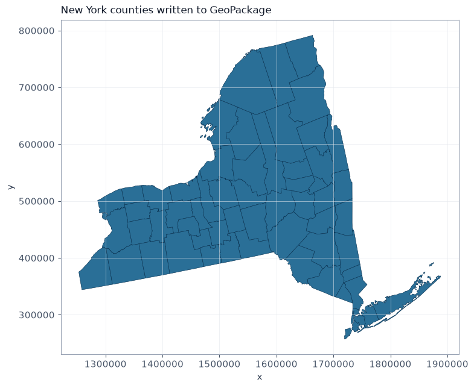

```python
# Re-open the written GeoPackage and plot New York counties
geopackage = COUNTY_DIR / "NY_County_PROJ.gpkg"  # Path written earlier in this notebook
with read_vector_data(geopackage) as dataset:  # Open the GeoPackage
    print(f"Driver:   {dataset.driver}")  # GDAL driver name
    print(f"Layer:    {dataset.layer.name}")  # Active layer name
    print(f"Features: {dataset.layer.feature_count}")  # Feature count
    print(f"CRS:      {dataset.layer.crs.name}")  # CRS name
    frame = dataset.layer.to_dataframe()  # Load as GeoDataFrame for plotting

# Call plot_layers()
plot_layers(
    [{"data": frame, "facecolor": FACE, "edgecolor": EDGE, "linewidth": 0.4, "label": "NY counties"}],  # Single style layer
    title="New York counties written to GeoPackage",  # Map title
    figsize=(8, 7),  # Figure size
    legend=False,  # No legend needed for one layer
)
```

### Write every sample format as a shapefile

These are the files Part 1 opens from `data/data_gdal`. Each non-empty layer is written with `write_shapefile`. `data/data_gdal` also contains GDAL autotest files that are truncated, empty, or invalid on purpose. Those files are not among the samples opened in Part 1, so they are not converted here.

A shapefile can store points, lines, or polygons, and only one of those families in a single file. Where a sample layer mixes types, or stores a geometry collection, each part is written to its own shapefile. The KMZ is built the same way as in Part 1: `kml/placemark.kml` is zipped as `doc.kml`.

```python
# Split mixed-geometry GDAL samples into one shapefile per geometry type
SHAPE_TYPES = {
    # Include Point
    "Point",
    # Include MultiPoint
    "MultiPoint",
    # Include LineString
    "LineString",
    # Include MultiLineString
    "MultiLineString",
    # Include LinearRing
    "LinearRing",
    # Include Polygon
    "Polygon",
    # Include MultiPolygon
    "MultiPolygon",
# Close mapping or set
}


# Define geometry_parts()
def geometry_parts(geometry):
    # If geometry is None or geometry.is_empty
    if geometry is None or geometry.is_empty:
        # Return result
        return []
    # If geometry.geom_type == "GeometryCollection"
    if geometry.geom_type == "GeometryCollection":
        # Set parts
        parts = []
        # Loop: child in geometry.geoms
        for child in geometry.geoms:
            # Call extend()
            parts.extend(geometry_parts(child))
        # Return result
        return parts
    # If geometry.geom_type in SHAPE_TYPES
    if geometry.geom_type in SHAPE_TYPES:
        # Return result
        return [geometry]
    # Return result
    return []


# Define safe_name()
def safe_name(text):
    # Set cleaned
    cleaned = "".join(character if character.isalnum() or character in "-_" else "_" for character in str(text))
    # Return result
    return cleaned.strip("_") or "layer"


# Define write_sample_as_shapefiles()
def write_sample_as_shapefiles(tag, source):
    # Include Write each layer of ``source`` to one shapefile per geometry type.
    """Write each layer of ``source`` to one shapefile per geometry type."""
    # Set rows
    rows = []
    # With open_vectors_data(source) as dataset
    with open_vectors_data(source) as dataset:
        # Try block
        try:
            # Set relative
            relative = str(Path(source).resolve().relative_to(DATA.resolve()))
        # Handle error
        except ValueError:
            # Set relative
            relative = Path(source).name
        # Loop: layer in dataset.layers
        for layer in dataset.layers:
            # Set grouped
            grouped = {}
            # Loop: feature in layer.read()
            for feature in layer.read():
                # Loop: part in geometry_parts(feature.geometry)
                for part in geometry_parts(feature.geometry):
                    # Call setdefault()
                    grouped.setdefault(part.geom_type, []).append(
                        # Statement
                        {"geometry": part, **feature.properties}
                    # Close multi-line expression
                    )
            # If not grouped
            if not grouped:
                # Call append()
                rows.append(
                    # Statement
                    {
                        # Statement
                        "format": tag,
                        # Statement
                        "source": relative,
                        # Statement
                        "layer": layer.name,
                        # Include geometry":
                        "geometry": "",
                        # Statement
                        "features": 0,
                        # Include shapefile":
                        "shapefile": "",
                        # Include status": "no geometry
                        "status": "no geometry",
                    # Close mapping or set
                    }
                # Close multi-line expression
                )
                # Statement
                continue
            # Set several
            several = len(grouped) > 1
            # Loop: geom_type, records in grouped.items()
            for geom_type, records in grouped.items():
                # Set stem
                stem = f"{tag}__{safe_name(Path(source).stem)}__{safe_name(layer.name)}"
                # If several
                if several:
                    # Set stem
                    stem = f"{stem}__{geom_type}"
                # Set destination
                destination = SAMPLE_DIR / f"{stem}.shp"
                # Try block
                try:
                    # Call write_shapefile()
                    write_shapefile(
                        # Statement
                        destination,
                        # Statement
                        records,
                        # Set layer
                        layer=safe_name(layer.name),
                        # Set crs
                        crs=layer.crs,
                        # Set encoding
                        encoding="UTF-8",
                        # Set overwrite
                        overwrite=True,
                    # Close multi-line expression
                    )
                    # Set status
                    status = "written"
                # Handle error
                except Exception as exc:
                    # Set status
                    status = f"{type(exc).__name__}: {exc}"
                # Call append()
                rows.append(
                    # Statement
                    {
                        # Statement
                        "format": tag,
                        # Statement
                        "source": relative,
                        # Statement
                        "layer": layer.name,
                        # Statement
                        "geometry": geom_type,
                        # Call "features": len()
                        "features": len(records),
                        # Statement
                        "shapefile": destination.name,
                        # Statement
                        "status": status,
                    # Close mapping or set
                    }
                # Close multi-line expression
                )
    # Return result
    return rows


# Set kmz_path
kmz_path = SAMPLE_DIR / "placemark.kmz"
# With zipfile.ZipFile(kmz_path, "w", compression=zipfile.ZIP_
with zipfile.ZipFile(kmz_path, "w", compression=zipfile.ZIP_DEFLATED) as archive:
    # Set archive.write(DATA / "kml" / "placemark.kml", arcname
    archive.write(DATA / "kml" / "placemark.kml", arcname="doc.kml")

# Set SAMPLES
SAMPLES = [
    # Call function()
    ("shapefile", DATA / "poly.shp"),
    # Call function()
    ("geojson", DATA / "geojson" / "grenada.geojson"),
    # Call function()
    ("geojsonseq", DATA / "geojsonseq" / "test.geojsonl"),
    # Call function()
    ("kml", DATA / "kml" / "samples.kml"),
    # Call function()
    ("kml", DATA / "kml" / "placemark.kml"),
    # Call function()
    ("kmz", kmz_path),
    # Call function()
    ("gml", DATA / "gml" / "gnis_pop_110.gml"),
    # Call function()
    ("gpx", DATA / "gpx" / "test.gpx"),
    # Call function()
    ("csv", DATA / "wkt.csv"),
    # Call function()
    ("mapinfo_tab", DATA / "mitab" / "all_geoms.tab"),
    # Call function()
    ("mapinfo_mif", DATA / "mitab" / "small.mif"),
    # Call function()
    ("mapinfo_mid", DATA / "mitab" / "small.mid"),
    # Call function()
    ("dxf", DATA / "dxf" / "assorted.dxf"),
    # Call function()
    ("dwg", DATA / "cad" / "line_r2000.dwg"),
    # Call function()
    ("dgn", DATA / "dgn" / "smalltest.dgn"),
    # Call function()
    ("filegdb", DATA / "openfilegdb" / "polygon_golden.gdb"),
    # Call function()
    ("spatialite", DATA / "sqlite" / "poly_spatialite.sqlite"),
    # Call function()
    ("flatgeobuf", DATA / "testfgb" / "poly.fgb"),
    # Call function()
    ("osm", DATA / "osm" / "test.osm"),
    # Call function()
    ("pbf", DATA / "osm" / "two_points.pbf"),
# Close multi-line expression
]

# Set sample_rows
sample_rows = []
# Loop: tag, path in SAMPLES
for tag, path in SAMPLES:
    # Call extend()
    sample_rows.extend(write_sample_as_shapefiles(tag, path))

# Set sample_report
sample_report = pd.DataFrame(sample_rows)
# Set written
written = sample_report[sample_report["status"] == "written"]
# Set display(written.reset_index(drop
display(written.reset_index(drop=True))
# Call print()
print(f"Shapefiles written: {len(written)}")
# Set skipped
skipped = sample_report[sample_report["status"] != "written"]
# If not skipped.empty
if not skipped.empty:
    # Call print()
    print("Layers with no shapefile geometry:")
    # Set display(skipped.reset_index(drop
    display(skipped.reset_index(drop=True))
```

|  | format | source | layer | geometry | features | shapefile | status |
| --- | --- | --- | --- | --- | --- | --- | --- |
| 0 | shapefile | poly.shp | poly | Polygon | 10 | shapefile__poly__poly.shp | written |
| 1 | geojson | geojson/grenada.geojson | grenada | MultiPolygon | 1 | geojson__grenada__grenada.shp | written |
| 2 | geojsonseq | geojsonseq/test.geojsonl | test | Point | 2 | geojsonseq__test__test.shp | written |
| 3 | kml | kml/samples.kml | Placemarks | Point | 3 | kml__samples__Placemarks.shp | written |
| 4 | kml | kml/samples.kml | Highlighted Icon | Point | 1 | kml__samples__Highlighted_Icon.shp | written |
| 5 | kml | kml/samples.kml | Ground Overlays | Polygon | 1 | kml__samples__Ground_Overlays.shp | written |
| 6 | kml | kml/samples.kml | Paths | LineString | 6 | kml__samples__Paths.shp | written |
| 7 | kml | kml/samples.kml | Google Campus | Polygon | 4 | kml__samples__Google_Campus.shp | written |
| 8 | kml | kml/samples.kml | Extruded Polygon | Polygon | 1 | kml__samples__Extruded_Polygon.shp | written |
| 9 | kml | kml/samples.kml | Absolute and Relative | Polygon | 4 | kml__samples__Absolute_and_Relative.shp | written |
| 10 | kml | kml/placemark.kml | placemark | Point | 1 | kml__placemark__placemark.shp | written |
| 11 | kmz | placemark.kmz | placemark | Point | 1 | kmz__placemark__placemark.shp | written |
| 12 | gml | gml/gnis_pop_110.gml | gnis_pop | Point | 20 | gml__gnis_pop_110__gnis_pop.shp | written |
| 13 | gpx | gpx/test.gpx | waypoints | Point | 2 | gpx__test__waypoints.shp | written |
| 14 | gpx | gpx/test.gpx | routes | LineString | 1 | gpx__test__routes.shp | written |
| 15 | gpx | gpx/test.gpx | tracks | MultiLineString | 1 | gpx__test__tracks.shp | written |
| 16 | gpx | gpx/test.gpx | route_points | Point | 3 | gpx__test__route_points.shp | written |
| 17 | gpx | gpx/test.gpx | track_points | Point | 4 | gpx__test__track_points.shp | written |
| 18 | csv | wkt.csv | wkt | Polygon | 3 | csv__wkt__wkt.shp | written |
| 19 | mapinfo_tab | mitab/all_geoms.tab | all_geoms | Point | 4 | mapinfo_tab__all_geoms__all_geoms__Point.shp | written |
| 20 | mapinfo_tab | mitab/all_geoms.tab | all_geoms | LineString | 6 | mapinfo_tab__all_geoms__all_geoms__LineStrin... | written |
| 21 | mapinfo_tab | mitab/all_geoms.tab | all_geoms | MultiLineString | 1 | mapinfo_tab__all_geoms__all_geoms__MultiLine... | written |
| 22 | mapinfo_tab | mitab/all_geoms.tab | all_geoms | Polygon | 5 | mapinfo_tab__all_geoms__all_geoms__Polygon.shp | written |
| 23 | mapinfo_tab | mitab/all_geoms.tab | all_geoms | MultiPoint | 2 | mapinfo_tab__all_geoms__all_geoms__MultiPoin... | written |
| 24 | mapinfo_mif | mitab/small.mif | small | Polygon | 2 | mapinfo_mif__small__small.shp | written |
| 25 | mapinfo_mid | mitab/small.mid | small | Polygon | 2 | mapinfo_mid__small__small.shp | written |
| 26 | dxf | dxf/assorted.dxf | entities | LineString | 5 | dxf__assorted__entities__LineString.shp | written |
| 27 | dxf | dxf/assorted.dxf | entities | Point | 7 | dxf__assorted__entities__Point.shp | written |
| 28 | dxf | dxf/assorted.dxf | entities | MultiLineString | 4 | dxf__assorted__entities__MultiLineString.shp | written |
| 29 | dxf | dxf/assorted.dxf | entities | Polygon | 6 | dxf__assorted__entities__Polygon.shp | written |
| 30 | dwg | cad/line_r2000.dwg | 0 | LineString | 1 | dwg__line_r2000__0.shp | written |
| 31 | dgn | dgn/smalltest.dgn | elements | Point | 1 | dgn__smalltest__elements__Point.shp | written |
| 32 | dgn | dgn/smalltest.dgn | elements | LineString | 2 | dgn__smalltest__elements__LineString.shp | written |
| 33 | dgn | dgn/smalltest.dgn | elements | Polygon | 1 | dgn__smalltest__elements__Polygon.shp | written |
| 34 | filegdb | openfilegdb/polygon_golden.gdb | OGRGeoJSON | MultiPolygon | 1 | filegdb__polygon_golden__OGRGeoJSON.shp | written |
| 35 | spatialite | sqlite/poly_spatialite.sqlite | poly | Polygon | 10 | spatialite__poly_spatialite__poly.shp | written |
| 36 | flatgeobuf | testfgb/poly.fgb | poly | Polygon | 10 | flatgeobuf__poly__poly.shp | written |
| 37 | osm | osm/test.osm | points | Point | 1 | osm__test__points.shp | written |
| 38 | osm | osm/test.osm | lines | LineString | 2 | osm__test__lines.shp | written |
| 39 | osm | osm/test.osm | multilinestrings | MultiLineString | 1 | osm__test__multilinestrings.shp | written |
| 40 | osm | osm/test.osm | multipolygons | MultiPolygon | 3 | osm__test__multipolygons.shp | written |
| 41 | osm | osm/test.osm | other_relations | Point | 1 | osm__test__other_relations__Point.shp | written |
| 42 | osm | osm/test.osm | other_relations | LineString | 1 | osm__test__other_relations__LineString.shp | written |
| 43 | pbf | osm/two_points.pbf | points | Point | 2 | pbf__two_points__points.shp | written |

```
Shapefiles written: 44
Layers with no shapefile geometry:
```

|  | format | source | layer | geometry | features | shapefile | status |
| --- | --- | --- | --- | --- | --- | --- | --- |
| 0 | kml | kml/samples.kml | Styles and Markup |  | 0 |  | no geometry |
| 1 | kml | kml/samples.kml | Screen Overlays |  | 0 |  | no geometry |
| 2 | kml | kml/samples.kml | Polygons |  | 0 |  | no geometry |
| 3 | pbf | osm/two_points.pbf | lines |  | 0 |  | no geometry |
| 4 | pbf | osm/two_points.pbf | multilinestrings |  | 0 |  | no geometry |
| 5 | pbf | osm/two_points.pbf | multipolygons |  | 0 |  | no geometry |
| 6 | pbf | osm/two_points.pbf | other_relations |  | 0 |  | no geometry |